# CIS 241

# May 1, 2025

# **1: Introduction**

The concept of autism was coined in 1911 by the German psychiatrist Eugen Bleuler to describe a symptom of the most severe cases of schizophrenia. Today, professionals recognize that autism spectrum disorder, also known as ASD, encompasses a range of symptoms and severity levels, hence why autism is a “spectrum” disorder. Data science plays a growing role in understanding and supporting individuals with autism, especially in areas like diagnosis, intervention, and personalized care. Many data sets about autism are widely available. I have chosen to use the **autism_prevalence_studies_20250325.csv** dataset from the CDC. The CDC makes this information available [at their website](https://data.cdc.gov/Public-Health-Surveillance/autism-prevalence-studies/9mw4-6adp/about_data). In this project, I will investigate the 207 studies available in this data. According to the CDC, “this data table provides a collection of information from peer-reviewed autism prevalence studies. Information reported from each study includes the autism prevalence estimate and additional study characteristics (e.g., case ascertainment and criteria). Data were abstracted and included if the study fulfilled the following criteria: The study was published in English, produced at least one autism prevalence estimate; and was population-based (any age range) within a defined geographic area.” (CDC, Hanley)

In terms of positionality, I bring my own autism diagnosis as personal bias. Having had various diagnosis on the ASD from multiple professionals, I need to remain neutral and consider this as a form of research. In terms of sociotechnical systems, I must remember that the data spans a long range of time, during which the descriptors used to diagnose autism have changed with the evolving researching and DSMV. Earlier results may have been wrong and would have different diagnosis with current DSMV standards. Considering the results from the Power perspective, it’s important to remember these results come from a variety of countries and medical institutions. Individuals from different countries have a wide range of interpretation and personal experience and may insert their own bias into diagnosis, as they interpret the information found in the DSMV differently or may have different versions of the DSMV available. In terms of narrative, I am hopeful that the results of my project will help shape the discussion about autism being circulated in the news today. The idea that there has been a “spike” in autism diagnosis is not because there are more individuals with autism; rather, the information about diagnosis has evolved over the years. It is my hope that these results validate that idea.

In this project, I hope to answer various questions about these studies. Does a study’s sample size directly correlate to how many cases were reported? Autism diagnosis has increased over the years, due to the implementation of the DSMV. Will my research show this? Using the studies’ features, is it possible to predict where a study was conducted? Do all countries have the same statistics in terms of autistic diagnosis? And if not, why might that be? What are the minimum and cutoff ages for correctly diagnosing autism? This could be helpful for parents and medical professionals, as the earlier an individual is diagnosed with autism, the earlier treatment and therapies can begin. If there is a cutoff age, what might it be? Can adults be diagnosed with autism and receive treatment? Is there a way to predict when a study was/will be published? This might validate the idea that more individuals are diagnosed now rather than in the past, due to the DSMV. In conclusion, I am very curious to see the results, as ASD is a part of my everyday life.

# **2: Data Wrangling, Explanation, and Exploration**

In this section, I will need to load the data so that I can wrangle it and begin my exploration with visualizations and other summary statistics. Since some of the cells in the `autism_prevalence_studies_20250325.csv` data were not in tidy form (i.e. they contained commas, semicolons, etc.), I needed to wrangle the data by creating new columns, modifying existing columns, and even deleting unecessary columns.

```python
import pandas as pd # Data Analysis
import numpy as np # Mathematical Calculations
import altair as alt # Data Visualization
alt.data_transformers.enable("vegafusion")
```

```
DataTransformerRegistry.enable('vegafusion')
```

In this block of code, I imported the necessary libraries, which were `pandas`, `numpy`, and `altair`. I imported `pandas` because it is the quintessential library for analyzing datasets in the form of .CSVs. I imported `numpy` because I will need to perform various calculations on the wrangled data. `numpy` will allow me to use several mathematical functions to set up a hypothesis test in order to determine if there are any correlations between my numerical variables. Lastly, I imported `altair` because it allows me to create the necessary visualizations about my data before running models. `altair` also allows me to see if there is a weak or strong correlation between two of my numerical variables.

```python
autism = pd.read_csv("autism_prevalence_studies_20250325.csv")
autism
```

|  | Author | Title | Year Published | Country | Area(s) | Age Range | Study Years | Case Identification Method | Case Criterion | Sample Size | ... | Diagnosis Age Range (months) | Diagnosis Mean Age (months) | Diagnosis Median Age (months) | IQ Score <70 (%) | Adaptive Score <70 (%) | Non-Verbal or Minimally Verbal (%) | Percentage of Individual Co-occurring Conditions | Autism Types Included | Link to Publication | CDC Calculated Values |
| --- | --- | --- | --- | --- | --- | --- | --- | --- | --- | --- | --- | --- | --- | --- | --- | --- | --- | --- | --- | --- | --- |
| 0 | Lotter | Epidemiology of Autistic Conditions in Young C... | 1966 | England | County of Middlesex | 8 to 10 | 1964 | survey (mail); health records | Kanner | 78000.0 | ... | NaN | NaN | NaN | 84.0 | NaN | 59.0 | NaN | autistic conditions | https://link.springer.com/article/10.1007/BF00... | IQ Score <70 (%); CI |
| 1 | Treffert | Epidemiology of infantile Autism | 1970 | USA | Wisconsin | 2 to 12 | 1962-1967 | health records | Kanner | 899750.0 | ... | NaN | NaN | NaN | NaN | NaN | NaN | NaN | classic infantile autism | https://www.ncbi.nlm.nih.gov/pubmed/5436867 | CI |
| 2 | Brask | A Prevalence investigation of Childhood Psychoses | 1972 | Denmark | Åarhus County | 2 to 14 | 1962 | health records; service provider records | clinical interpretation | 46500.0 | ... | NaN | NaN | NaN | NaN | NaN | NaN | NaN | autistic syndrome | NaN | CI |
| 3 | Wing, et al. | The prevalence of early childhood autism: comp... | 1976 | England | Camberwall | 5 to 14 | 1974 | registry; survey (unspecified) | clinical interpretation | 25000.0 | ... | NaN | NaN | NaN | NaN | NaN | NaN | NaN | early childhood autism | https://pubmed.ncbi.nlm.nih.gov/935299/ | CI |
| 4 | Wing, et al. | Severe impairments of social interaction and a... | 1979 | England | Camberwell | 0 to 14 | 1970 | registry; service provider records | Kanner; clinical interpretation | 35000.0 | ... | NaN | NaN | NaN | 70.0 | NaN | 59.0 | 0 (Down syndrome) | autism | https://www.ncbi.nlm.nih.gov/pubmed/155684 | IQ Score <70 (%); CI |
| ... | ... | ... | ... | ... | ... | ... | ... | ... | ... | ... | ... | ... | ... | ... | ... | ... | ... | ... | ... | ... | ... |
| 202 | Maenner, et al. | Prevalence and Characteristics of Autism Spect... | 2021 | USA | Arizona; Arkansas; California; Georgia; Maryla... | 8 | 2018 | health records; education records | DSM-IV-TR; DSM-5; ICD-9; ICD-10; a special edu... | 220281.0 | ... | 36.0 - 63.0 | NaN | 50 | 35.2 | NaN | NaN | NaN | ASD (not specified) | https://pubmed.ncbi.nlm.nih.gov/34855725/ | none |
| 203 | Roman-Urrestarazu, et al. | Association of Race/Ethnicity and Social Disad... | 2021 | England | National | 5 to 19 | 2017 | registry | a special education classification of autism | 7047238.0 | ... | NaN | NaN | NaN | NaN | NaN | NaN | NaN | ASD (not specified) | https://pubmed.ncbi.nlm.nih.gov/33779707/ | CI; White:Black prevalence ratio |
| 204 | Shenouda, et al. | Prevalence of autism spectrum disorder in a la... | 2022 | USA | New Jersey | 8 | 2016 | health records; education records | DSM-5; clinical interpretation | 26083.0 | ... | NaN | NaN | NaN | 25.2 | NaN | NaN | NaN | ASD (not specified) | https://pubmed.ncbi.nlm.nih.gov/34672116/ | White:Hispanic prevalence ratio; White:Black p... |
| 205 | Villegas-Lirola, et al. | Prevalence of Autism Spectrum Disorder in Chil... | 2022 | Spain | Andalusia | 6 to 12 | 2020-2021 | registry | ICD-10 | NaN | ... | NaN | 53.3 | 42 | NaN | NaN | NaN | NaN | Autism, Asperger Syndrome, Pervasive Developme... | https://pubmed.ncbi.nlm.nih.gov/36076115/ | number of cases; sex ratio; mean diagnosis age... |
| 206 | Yoo, et al. | Prevalence and Premature Mortality Statistics ... | 2022 | Korea | National | 0 to 8 | 2010-2020 | health records | ICD-10 | 4989351.0 | ... | NaN | NaN | NaN | NaN | NaN | NaN | NaN | ASD (not specified) | https://pubmed.ncbi.nlm.nih.gov/34981677/ | CI; Male:Female prevalence ratio |

207 rows × 26 columns

Before I can even wrangle and explore my data, I need to read it in by using the `.read_csv()` method in the `pandas` library. As stated, the .csv file is titled `autism_prevalence_studies_20250325.csv`, so I made that the argument of the `.read_csv()` method. After reading in the .csv, I also made sure to load in the data so that I perform an intial scan on the dataframe. I will be looking for several things, including columns that I will use in both my hypothesis test and model.

- The study was published in English;
- The study produced at least one autism prevalence estimate; and
- The study was population-based (any age range) within a defined geographic area.

```python
autism.info()
```

```
<class 'pandas.core.frame.DataFrame'>
RangeIndex: 207 entries, 0 to 206
Data columns (total 26 columns):
 #   Column                                            Non-Null Count  Dtype
---  ------                                            --------------  -----
 0   Author                                            207 non-null    object
 1   Title                                             207 non-null    object
 2   Year Published                                    207 non-null    int64
 3   Country                                           207 non-null    object
 4   Area(s)                                           202 non-null    object
 5   Age Range                                         202 non-null    object
 6   Study Years                                       185 non-null    object
 7   Case Identification Method                        207 non-null    object
 8   Case Criterion                                    207 non-null    object
 9   Sample Size                                       192 non-null    float64
```

[output cut: 18 more lines]

This is a list of all of the feature names that describe the `autism` dataset, as well as their datatype and the number of non-null values they have. As you can see from the data and the column list above, the data has 26 columns and 207 rows. Each row represents a unique study with its various statistics about individuals with autism. Some of the most important features include `Sample Size`, `Autism Types Included`, `Country`, and `ASD Prevalence Estimate per 1,000`. The columns represent all of the individual features for each study.

There are multiple issues with this dataset that will have to be addressed. The biggest issue by far is that some columns have nothing but null values, meaning that I will have to either not include them in my studies or add values to them. Another issue about this dataset is that some statitistics are classified as "objects" (strings) because they contain characters that are not digits (e.g. the alphabet, parenthesis, semicolons, etc.). This will be fixed by removing all of the non-numerical characters. Lastly, some cells have more than one value, which can be fixed by removing them or changing them to say "multiple methods/types".

```python
autism = autism.fillna("0.0")
```

This line of code fills all of the NaN values with the string "0.0". This is because even though some statistics have numerical data, they are classified as "objects" (or strings) because as stated previously, they contain non-numerical characters.

These next several lines of code take on the role of One-hot data encoding since the values in the `Case Identification Method`, `Case Criterion`, and `Autism Types Included` all have cells with more than one variable, which causes the dataset to be "untidy".

```python
mylist = []
for i in range(len(autism)): # Iterate over every item in the autism dataset
    index = 0
    for j in range(len(autism.at[i,"Case Identification Method"])): # Iterate through all of the items in the ith list from the "method" variable
        if " (" in autism.at[j, "Case Identification Method"]:
            index = autism.at[j, "Case Identification Method"].index(" (")
            mylist.append(autism.at[j, "Case Identification Method"][0:index])
        else:
            mylist.append(autism.at[j, "Case Identification Method"])
mylist = pd.Series(mylist).str.split('; ')
mylist2 = []
for i in range(len(mylist)):
    for j in range(len(mylist[i])):
        mylist2.append(mylist[i][j])
mylist2 = pd.unique(pd.Series(mylist2))
```

This block of code creates a list named `mylist`, which will contain all of the individual Case Identification Methods used in each study. Note that multiple cells in the `Case Identification Method` column have parenthesis, so the block of code accounts for this by splitting the elements in the `Case Identification Method` by the `(` string if it is contained in the current "cell". After creating the list, it is then transformed into a pandas Series of strings split by semicolons because the original `Case Identification Method` column separates each method by semicolons.

Next, another list named `mylist2` is created to contain all of the unique elements (case identification methods used) in the original `mylist`. It does so by iterating through all of the elements in `mylist` and adding each element to the second list. Lastly, `mylist2` is turned into a pandas Series with only its (the list's) unique elements using the `pd.unique()` method.

```python
mylist2[5] = "other method" # Rename index 5 of mylist2
mylist2
```

```
array(['survey', 'health records', 'service provider records', 'registry',
       'education records', 'other method', 'special needs registry'],
      dtype=object)
```

Because the `Case Criterion` column also has "other" as a unique element, in order to avoid disambiguity, the 6th element (AKA index 5) in `mylist2` is changed to have the value of "other method".

```python
method = list(mylist2)
```

This line of code assigns `mylist2` as a list to `method` as it will be used for future models.

```python
autism.assign(method1='',method2='',method3='',method4='',method5='',method6='',method7='')
# Create 7 new columns based on the 7 possible Case Identification Methods
```

|  | Author | Title | Year Published | Country | Area(s) | Age Range | Study Years | Case Identification Method | Case Criterion | Sample Size | ... | Autism Types Included | Link to Publication | CDC Calculated Values | method1 | method2 | method3 | method4 | method5 | method6 | method7 |
| --- | --- | --- | --- | --- | --- | --- | --- | --- | --- | --- | --- | --- | --- | --- | --- | --- | --- | --- | --- | --- | --- |
| 0 | Lotter | Epidemiology of Autistic Conditions in Young C... | 1966 | England | County of Middlesex | 8 to 10 | 1964 | survey (mail); health records | Kanner | 78000.0 | ... | autistic conditions | https://link.springer.com/article/10.1007/BF00... | IQ Score <70 (%); CI |  |  |  |  |  |  |  |
| 1 | Treffert | Epidemiology of infantile Autism | 1970 | USA | Wisconsin | 2 to 12 | 1962-1967 | health records | Kanner | 899750.0 | ... | classic infantile autism | https://www.ncbi.nlm.nih.gov/pubmed/5436867 | CI |  |  |  |  |  |  |  |
| 2 | Brask | A Prevalence investigation of Childhood Psychoses | 1972 | Denmark | Åarhus County | 2 to 14 | 1962 | health records; service provider records | clinical interpretation | 46500.0 | ... | autistic syndrome | 0.0 | CI |  |  |  |  |  |  |  |
| 3 | Wing, et al. | The prevalence of early childhood autism: comp... | 1976 | England | Camberwall | 5 to 14 | 1974 | registry; survey (unspecified) | clinical interpretation | 25000.0 | ... | early childhood autism | https://pubmed.ncbi.nlm.nih.gov/935299/ | CI |  |  |  |  |  |  |  |
| 4 | Wing, et al. | Severe impairments of social interaction and a... | 1979 | England | Camberwell | 0 to 14 | 1970 | registry; service provider records | Kanner; clinical interpretation | 35000.0 | ... | autism | https://www.ncbi.nlm.nih.gov/pubmed/155684 | IQ Score <70 (%); CI |  |  |  |  |  |  |  |
| ... | ... | ... | ... | ... | ... | ... | ... | ... | ... | ... | ... | ... | ... | ... | ... | ... | ... | ... | ... | ... | ... |
| 202 | Maenner, et al. | Prevalence and Characteristics of Autism Spect... | 2021 | USA | Arizona; Arkansas; California; Georgia; Maryla... | 8 | 2018 | health records; education records | DSM-IV-TR; DSM-5; ICD-9; ICD-10; a special edu... | 220281.0 | ... | ASD (not specified) | https://pubmed.ncbi.nlm.nih.gov/34855725/ | none |  |  |  |  |  |  |  |
| 203 | Roman-Urrestarazu, et al. | Association of Race/Ethnicity and Social Disad... | 2021 | England | National | 5 to 19 | 2017 | registry | a special education classification of autism | 7047238.0 | ... | ASD (not specified) | https://pubmed.ncbi.nlm.nih.gov/33779707/ | CI; White:Black prevalence ratio |  |  |  |  |  |  |  |
| 204 | Shenouda, et al. | Prevalence of autism spectrum disorder in a la... | 2022 | USA | New Jersey | 8 | 2016 | health records; education records | DSM-5; clinical interpretation | 26083.0 | ... | ASD (not specified) | https://pubmed.ncbi.nlm.nih.gov/34672116/ | White:Hispanic prevalence ratio; White:Black p... |  |  |  |  |  |  |  |
| 205 | Villegas-Lirola, et al. | Prevalence of Autism Spectrum Disorder in Chil... | 2022 | Spain | Andalusia | 6 to 12 | 2020-2021 | registry | ICD-10 | 0.0 | ... | Autism, Asperger Syndrome, Pervasive Developme... | https://pubmed.ncbi.nlm.nih.gov/36076115/ | number of cases; sex ratio; mean diagnosis age... |  |  |  |  |  |  |  |
| 206 | Yoo, et al. | Prevalence and Premature Mortality Statistics ... | 2022 | Korea | National | 0 to 8 | 2010-2020 | health records | ICD-10 | 4989351.0 | ... | ASD (not specified) | https://pubmed.ncbi.nlm.nih.gov/34981677/ | CI; Male:Female prevalence ratio |  |  |  |  |  |  |  |

207 rows × 33 columns

Since there are 7 unique case identification methods used in each study, 7 new columns are created based on those methods.

```python
mylist2 = pd.DataFrame(mylist2) # Convert mylist2 to a pandas DataFrame
# Iterate through all the items in the mylist DataFrame
for i in range(len(mylist2)):
    # Iterate through all of the items in the autism dataset
    for j in range(len(autism)):
        # Case 1: is the current item from the ith list in the jth cell of the "Case Identification Method" column?
        if mylist2[0][i] in autism.at[j, "Case Identification Method"]:
            autism.at[j,mylist2[0][i]]=True # Assigns True to the jth cell of the ith element of the 0th index of mylist
        # Case 2: is the current item from the ith list NOT in the jth cell of the "Case Identification Method" column?
        else:
            autism.at[j,mylist2[0][i]]=False # Assigns False to the jth cell of the ith element of the 0th index of mylist
```

This block of code transforms the unique Series of `mylist2` into a DataFrame so that each of its elements can be iterated. The code also assigns the corresponding True or False value for each cell in the 7 newly created columns. It does so by iterating through all of the unique elements in `mylist2`, as well as checking to see if the current element in `mylist2` is contained in the currently checked cell of the `Case Identification Method` column. If the Case Identification Method is used in a study, the code assigns True for the value of the current cell in its corresponding column. (E.G the code assigns "True" in row 44 of the "other method" column if "other methods" are contained in the 44th row of the `Case Identification Method` column, and assigns False otherwise.)

```python
autism.drop("Case Identification Method", axis=1, inplace = True) # Removes the Case Identification Method column
```

Since the 7 newly created columns tell us if a specific Case Indentification Method is used in a study or not, we do not need the original `Case Identification Method` column anymore. Removing this column makes the current `autism` dataset "tidier".

```python
mylist = []
for i in range(len(autism)): # Iterate over every item in the autism dataset
    index = 0
    for j in range(len(autism.at[i,"Case Criterion"])): # Iterate through all of the items in the ith list from the "method" variable
        if " (" in autism.at[j, "Case Criterion"]:
            index = autism.at[j, "Case Criterion"].index(" (")
            mylist.append(autism.at[j, "Case Criterion"][0:index])
        else:
            mylist.append(autism.at[j, "Case Criterion"])
mylist = pd.Series(mylist).str.split('; ')
mylist2 = []
for i in range(len(mylist)):
    for j in range(len(mylist[i])):
        mylist2.append(mylist[i][j])
mylist2 = pd.unique(pd.Series(mylist2))
```

This block of code empties `mylist` since it will now contain all of the individual Case Criteria used in each study. Note that much like the `Case Identification Method` column, multiple cells in the `Case Criterion` column also have parenthesis, so the block of code accounts for this by splitting the elements in the `Case Criterion` by the `(` string if it is contained in the current "cell". After creating the list, it is then transformed into a pandas Series of strings split by semicolons because much like the `Case Identification Method` column, the original `Case Criterion` column also separates each case criterion by semicolons.

Next, `mylist2` is emptied to contain all of the unique elements (case criteria used) in the original `mylist` (which contains all of the individual case criteria). It does so by iterating through all of the elements in `mylist` and adding each element to the second list. Lastly, `mylist2` is turned into a pandas Series with only its (the list's) unique elements using the `pd.unique()` method.

```python
mylist2[5] = "other criterion"
mylist2
```

```
array(['Kanner', 'clinical interpretation', 'Rutter', 'DSM-III',
       'autism test', 'other criterion', 'DSM-III-R', 'ICD-10',
       'parental report', 'ICD-9', 'DSM', 'DSM-IV', 'DMS-IV',
       'special education classification', 'DSM-IV-TR',
       'clinician interpretation', 'receipt of autism-specific services',
       'receipt of autism specific services', 'survey', 'DSM-5', 'ICD-8'],
      dtype=object)
```

Because the `Case Identification Method` column also has "other" as a unique element, in order to avoid disambiguity, the 6th element (AKA index 5) in `mylist2` is changed to have the value of "other criterion".

```python
criterion=list(mylist2)
```

```python
autism.assign(criteria1='',criteria2='',criteria3='',criteria4='',criteria5='',criteria6='',criteria7='',criteria8='',criteria9='',criteria10='',criteria11='',criteria12='',criteria13='',criteria14='',criteria15='',criteria16='',criteria17='',criteria18='',criteria19='',criteria20='',criteria21='')
# Assigns a whopping 21 columns
```

|  | Author | Title | Year Published | Country | Area(s) | Age Range | Study Years | Case Criterion | Sample Size | Number of Cases | ... | criteria12 | criteria13 | criteria14 | criteria15 | criteria16 | criteria17 | criteria18 | criteria19 | criteria20 | criteria21 |
| --- | --- | --- | --- | --- | --- | --- | --- | --- | --- | --- | --- | --- | --- | --- | --- | --- | --- | --- | --- | --- | --- |
| 0 | Lotter | Epidemiology of Autistic Conditions in Young C... | 1966 | England | County of Middlesex | 8 to 10 | 1964 | Kanner | 78000.0 | 35.0 | ... |  |  |  |  |  |  |  |  |  |  |
| 1 | Treffert | Epidemiology of infantile Autism | 1970 | USA | Wisconsin | 2 to 12 | 1962-1967 | Kanner | 899750.0 | 69.0 | ... |  |  |  |  |  |  |  |  |  |  |
| 2 | Brask | A Prevalence investigation of Childhood Psychoses | 1972 | Denmark | Åarhus County | 2 to 14 | 1962 | clinical interpretation | 46500.0 | 20.0 | ... |  |  |  |  |  |  |  |  |  |  |
| 3 | Wing, et al. | The prevalence of early childhood autism: comp... | 1976 | England | Camberwall | 5 to 14 | 1974 | clinical interpretation | 25000.0 | 12.0 | ... |  |  |  |  |  |  |  |  |  |  |
| 4 | Wing, et al. | Severe impairments of social interaction and a... | 1979 | England | Camberwell | 0 to 14 | 1970 | Kanner; clinical interpretation | 35000.0 | 17.0 | ... |  |  |  |  |  |  |  |  |  |  |
| ... | ... | ... | ... | ... | ... | ... | ... | ... | ... | ... | ... | ... | ... | ... | ... | ... | ... | ... | ... | ... | ... |
| 202 | Maenner, et al. | Prevalence and Characteristics of Autism Spect... | 2021 | USA | Arizona; Arkansas; California; Georgia; Maryla... | 8 | 2018 | DSM-IV-TR; DSM-5; ICD-9; ICD-10; a special edu... | 220281.0 | 5058.0 | ... |  |  |  |  |  |  |  |  |  |  |
| 203 | Roman-Urrestarazu, et al. | Association of Race/Ethnicity and Social Disad... | 2021 | England | National | 5 to 19 | 2017 | a special education classification of autism | 7047238.0 | 119821.0 | ... |  |  |  |  |  |  |  |  |  |  |
| 204 | Shenouda, et al. | Prevalence of autism spectrum disorder in a la... | 2022 | USA | New Jersey | 8 | 2016 | DSM-5; clinical interpretation | 26083.0 | 942.0 | ... |  |  |  |  |  |  |  |  |  |  |
| 205 | Villegas-Lirola, et al. | Prevalence of Autism Spectrum Disorder in Chil... | 2022 | Spain | Andalusia | 6 to 12 | 2020-2021 | ICD-10 | 0.0 | 4678.0 | ... |  |  |  |  |  |  |  |  |  |  |
| 206 | Yoo, et al. | Prevalence and Premature Mortality Statistics ... | 2022 | Korea | National | 0 to 8 | 2010-2020 | ICD-10 | 4989351.0 | 35529.0 | ... |  |  |  |  |  |  |  |  |  |  |

207 rows × 53 columns

Since there are 21 unique case criteria used in each study, 21 new columns are created based on those criteria.

```python
mylist2 = pd.DataFrame(mylist2) # Convert mylist2 to a pandas DataFrame
mylist2
# Iterate through all the items in the mylist DataFrame
for i in range(len(mylist2)):
    # Iterate through all of the items in the autism dataset
    for j in range(len(autism)):
        # Case 1: is the current item from the ith list in the jth cell of the "Case Identification Method" column?
        if mylist2[0][i] in autism.at[j, "Case Criterion"]:
            autism.at[j,mylist2[0][i]]=True # Assigns True to the jth cell of the ith element of the 0th index of mylist
        # Case 2: is the current item from the ith list NOT in the jth cell of the "Case Identification Method" column?
        else:
            autism.at[j,mylist2[0][i]]=False # Assigns False to the jth cell of the ith element of the 0th index of mylist
```

This block of code transforms the unique Series of `mylist2` into a DataFrame so that each of its elements can be iterated. The code also assigns the corresponding True or False value for each cell in the 21 newly created columns. It does so by iterating through all of the unique elements in `mylist2`, as well as checking to see if the current element in `mylist2` is contained in the currently checked cell of the `Case Criterion` column. If a specific Case Criterion is used in a study, the code assigns True for the value of the current cell in its corresponding column. (E.G the code assigns "True" in row 75 of the "DSM" column if "DSM" is contained in the 75th row of the `Case Criterion` column, and assigns False otherwise.)

```python
autism.drop("Case Criterion", axis=1, inplace = True) # Drops the Case Criterion Column as it is not needed anymore
```

Since the newly created columns tell us if a specific Case Criterion is used in a study or not, we do not need the original `Case Criterion` column anymore. Removing this column also makes the current `autism` dataset "tidier".

```python
mylist = []
for i in range(len(autism)): # Iterate over every item in the autism dataset
    index = 0
    for j in range(len(autism.at[i,"Autism Types Included"])): # Iterate through all of the items in the ith list from the "method" variable
        if " (" in autism.at[j, "Autism Types Included"]:
            index = autism.at[j, "Autism Types Included"].index(" (")
            mylist.append(autism.at[j, "Autism Types Included"][0:index])
        else:
            mylist.append(autism.at[j, "Autism Types Included"])
mylist = pd.Series(mylist).str.split(', ')
mylist2 = []
for i in range(len(mylist)):
    for j in range(len(mylist[i])):
        mylist2.append(mylist[i][j])
mylist2 = pd.unique(pd.Series(mylist2))
mylist2
```

```
array(['autistic conditions', 'classic infantile autism',
       'autistic syndrome', 'early childhood autism', 'autism',
       'early infantile autism', 'autistic mental retardation',
       'childhood autism', 'infantile autism', 'autistic-like conditions',
       'childhood onset PDD', 'atypial PDD', 'all PDD', 'simple autism',
       'autism with major neurological abnormalities', 'autism syndrome',
       'autistic disorder', 'autism-like conditions', 'atypical autism',
       'disintegrative disorder', 'Asperger syndrome',
       'other autistic-like conditions', 'core autism', 'PDD', 'OMRS',
       'Rett syndrome', 'AD', 'PDD-NOS', 'full syndrome autism',
       'autism spectrum condition', 'childhood disintegrative disorder',
       'ASD', 'high functioning autism', 'asperger syndrome',
       'autistic disorder; Asperger syndrome', 'PDD/ASD', 'other PDD',
       'childhood autism/autistic disorder', 'atypical autism/PDD-NOS',
       "Asperger's disorder", 'Autistic Spectrum Conditions',
       'autism spectrum conditions', 'and other ASDs',
       'autism spectrum disorder trait', 'Rett syndrone',
       'other autism spectrum', 'autism disorder',
       'PDD-NOS including atypical autism or Asperger syndrome',
       'other specified pervasive development disorder'], dtype=object)
```

Next, `mylist2` is emptied to contain all of the unique elements (types of autism found) in the original `mylist` (which contains all of the individual types of autism). It does so by iterating through all of the elements in `mylist` and adding each element to the second list. Lastly, `mylist2` is turned into a pandas Series with only its (the list's) unique elements using the `pd.unique()` method.

Note that since there are multiple typos and other character-separating strings, they will not be included for my "tidied" dataset.

```python
mylist3 = ['autistic-like conditions', 'Asperger syndrome', 'PDD', 'autism spectrum conditions',
          'ASD', 'high functioning autism', 'PDD-NOS', 'early childhood autism', 'autistic mental retardation',
          'childhood autism', 'childhood onset PDD', 'autistic disorder', 'autism', 'atypical autism', 'core autism', 'OMRS']
```

This line of code creates a new list titled `mylist3` based on the 16 most important types of autism, in my opinion, found in each study. The following types of autism included in this list:

1. autistic-like conditions
2. Asperger syndrome
3. PDD
4. autism spectrum conditions
5. ASD
6. high functioning autism
7. PDD-NOS
8. early childhood autism
9. autistic mental retardation
10. childhood autism
11. childhood onset PDD
12. autistic disorder
13. autism
14. atypical autism
15. core autism
16. OMRS

I chose these 16 types of autism because I was diagnosed with the first 8 types of autism from different medical professionals. The other 8 types of autism are the most commonly known types of autism and can cover a wide range of affected individuals on the autism spectrum.

```python
types = mylist3
```

This line of code assigns `mylist3` to `types` as it will be used for future models.

```python
autism.assign(criteria1='',criteria2='',criteria3='',criteria4='',criteria5='',criteria6='',criteria7='',criteria8='',criteria9='',criteria10='',criteria11='',criteria12='',criteria13='',criteria14='',criteria15='',criteria16='')
# Create 16 new columns
```

|  | Author | Title | Year Published | Country | Area(s) | Age Range | Study Years | Sample Size | Number of Cases | ASD Prevalence Estimate per 1,000 | ... | criteria7 | criteria8 | criteria9 | criteria10 | criteria11 | criteria12 | criteria13 | criteria14 | criteria15 | criteria16 |
| --- | --- | --- | --- | --- | --- | --- | --- | --- | --- | --- | --- | --- | --- | --- | --- | --- | --- | --- | --- | --- | --- |
| 0 | Lotter | Epidemiology of Autistic Conditions in Young C... | 1966 | England | County of Middlesex | 8 to 10 | 1964 | 78000.0 | 35.0 | 0.450 | ... |  |  |  |  |  |  |  |  |  |  |
| 1 | Treffert | Epidemiology of infantile Autism | 1970 | USA | Wisconsin | 2 to 12 | 1962-1967 | 899750.0 | 69.0 | 0.077 | ... |  |  |  |  |  |  |  |  |  |  |
| 2 | Brask | A Prevalence investigation of Childhood Psychoses | 1972 | Denmark | Åarhus County | 2 to 14 | 1962 | 46500.0 | 20.0 | 0.430 | ... |  |  |  |  |  |  |  |  |  |  |
| 3 | Wing, et al. | The prevalence of early childhood autism: comp... | 1976 | England | Camberwall | 5 to 14 | 1974 | 25000.0 | 12.0 | 4.480 | ... |  |  |  |  |  |  |  |  |  |  |
| 4 | Wing, et al. | Severe impairments of social interaction and a... | 1979 | England | Camberwell | 0 to 14 | 1970 | 35000.0 | 17.0 | 0.490 | ... |  |  |  |  |  |  |  |  |  |  |
| ... | ... | ... | ... | ... | ... | ... | ... | ... | ... | ... | ... | ... | ... | ... | ... | ... | ... | ... | ... | ... | ... |
| 202 | Maenner, et al. | Prevalence and Characteristics of Autism Spect... | 2021 | USA | Arizona; Arkansas; California; Georgia; Maryla... | 8 | 2018 | 220281.0 | 5058.0 | 23.000 | ... |  |  |  |  |  |  |  |  |  |  |
| 203 | Roman-Urrestarazu, et al. | Association of Race/Ethnicity and Social Disad... | 2021 | England | National | 5 to 19 | 2017 | 7047238.0 | 119821.0 | 17.600 | ... |  |  |  |  |  |  |  |  |  |  |
| 204 | Shenouda, et al. | Prevalence of autism spectrum disorder in a la... | 2022 | USA | New Jersey | 8 | 2016 | 26083.0 | 942.0 | 36.000 | ... |  |  |  |  |  |  |  |  |  |  |
| 205 | Villegas-Lirola, et al. | Prevalence of Autism Spectrum Disorder in Chil... | 2022 | Spain | Andalusia | 6 to 12 | 2020-2021 | 0.0 | 4678.0 | 8.650 | ... |  |  |  |  |  |  |  |  |  |  |
| 206 | Yoo, et al. | Prevalence and Premature Mortality Statistics ... | 2022 | Korea | National | 0 to 8 | 2010-2020 | 4989351.0 | 35529.0 | 7.120 | ... |  |  |  |  |  |  |  |  |  |  |

207 rows × 67 columns

Because I chose 16 unique types of autism found in each study, 16 new columns are created based on those tyoes of autism.

```python
mylist3 = pd.DataFrame(mylist3) # Convert mylist3 to a pandas DataFrame
mylist3
# Iterate through all the items in the mylist3 DataFrame
for i in range(len(mylist3)):
    # Iterate through all of the items in the autism dataset
    for j in range(len(autism)):
        # Case 1: is the current item from the ith list in the jth cell of the "Case Identification Method" column?
        if mylist3[0][i] in autism.at[j, "Autism Types Included"]:
            autism.at[j,mylist3[0][i]]=True # Assigns True to the jth cell of the ith element of the 0th index of mylist
        # Case 2: is the current item from the ith list NOT in the jth cell of the "Case Identification Method" column?
        else:
            autism.at[j,mylist3[0][i]]=False # Assigns False to the jth cell of the ith element of the 0th index of mylist
```

This block of code transforms the unique Series of `mylist3` into a DataFrame so that each of its elements can be iterated. The code also assigns the corresponding True or False value for each cell in the 16 newly created columns. It does so by iterating through all of the unique elements in `mylist3`, as well as checking to see if the element in `mylist3` is contained in the currently checked cell of the `Autism Types Included` column. If the Case Identification Method is used in a study, the code assigns True for the value of the current cell in its corresponding column. (E.G the code assigns "True" in row 99 of the "high functioning autism" column if "high functioning autism" is contained in the 99th row of the `Autism Types Included` column, and assigns False otherwise.)

```python
autism.drop("Autism Types Included", axis=1, inplace = True) # Drops the Autism Types Included column
```

Since the newly created columns tell us if a specific type of autism is found in a study or not, we do not need the original `Autism Types Included` column anymore. Removing this column makes the current `autism` dataset "tidier".

```python
autism.drop("CDC Calculated Values", axis=1, inplace = True) # Drops the CDC Calculated Values column
```

Since I do not care about the CDC calculated values, I decided to drop this column altogether. This created a new potential problem at the cost of making the dataset "tidier".

I created 44 new columns to the existing data, which was my solution to tidying up the data. This is because there are 7 unique Case Identification Methods, 21 unique Case Criteria, and 16 unique types of autism. These several lines of code above transfrom these subsets from the `Case Identification Method`, `Case Criterion`, and `Autism Types Included` columns and converts them to either being in or not in the study.

```python
autism.at[16, "Age Range"] = "1.5 to 5.5" # Change value of cell at row 16 of "Age Range" column.
```

This line of code changes the cell at row 16 of the `Age Range` column to "1.5 to 5.5" since there is a space between the 5 and the decimal point (i.e. 5. 5 instead of 5.5).

```python
autism.at[95, "Age Range"] = "16" # Change value of cell at row 95 of "Age Range" column.
```

This line of code changes the value of the cell at row 95 of the `Age Range` column to a single value because there is a ">=" character. This also has the unique effect of making the study at row 95 have no specified maximum age, so that will have to be fixed.

```python
autism.at[199,"Age Range"] = "4 to 11" # Change value of cell at row 199 of "Age Range" column.
```

This line of code changes the value of the cell at row 199 of the `Age Range` column because there are two age ranges: One between 4-5 years old and another between 10-11 years old. In order to keep the traditional format of age ranges being "minimum age to maximum age", I decided to have the age range of this study go from 4 to 11 years old.

```python
# Create 2 lists to represent the minimum and maximum age of participants in the study
age0 = []
age1 = []
# Iterate through all the rows in autism
for i in range(len(autism)):
    # Case 1: Does a space separate any cells in the "Age Range" column
    if " " in autism["Age Range"][i]:
        age0.append(float(autism.at[i,"Age Range"].replace(" to ", ",").split(",")[0]))
        age1.append(float(autism.at[i,"Age Range"].replace(" to ", ",").split(",")[1]))
    # Case 2: There is only one age in the current cell
    else:
        age0.append(float(autism.at[i,"Age Range"].replace(" to ", ",").split(",")[0]))
        age1.append(float(autism.at[i,"Age Range"].replace(" to ", ",").split(",")[0]))
```

This block of code creates two lists, which will contain the minimum and maximum ages of the participants of each unique study. The code does so by iterating through all of the individual studies and checking to see if the age range has one or two numerical values. If a study does contain two numerical values, the smaller of the two numbers is added to the `age0` list while the larger number is appended to the `age1` list. Otherwise, the same value is added to both the `age0` and `age1` lists. (E.G: Study 1 has an age range between 4 to 8 years old, so 4 is appended to `age0` and 8 is appended to `age1`).

```python
age1[95] = 100.0 # Set maximum age of row 95 to 100.0
```

Since the 95th row of the `autism` dataset has no speicified maximum age value, I decided to set one (a maximum age) of 100 years old.

```python
# Create 2 new columns based on the minimuum and maximum ages of each study's participants
autism = autism.assign(min_age=age0)
autism = autism.assign(max_age=age1)
autism.drop("Age Range", axis=1, inplace = True) # Drop the "Age Range" column as it is now irrelevant
```

This block of code creates two columns based on the participants' ages for each study, with one column having the youngest ages and the other having the oldest ages. It also removes the `Age Range` column because we now have numerical values for minimum and maximum ages of a study's participants. Dropping the `Age Range` column is one more step to "tidying up" the `autism` dataset.

```python
autism.at[119, "Diagnosis Age Range (months)"] = "13-172" # Since there are multiple age ranges included, this cell must be changed to have only one age range.
```

This line of code changes the 119th row of the `Diagnosis Age Range (months)` column to fit the traditional format of the other cells. This is because there are multiple age ranges included, which would be hard to properly "wrangle". To combat this, I chose the smallest and largest values in this cell, which were 13 and 172, respectively. I then changed the cell's value to "13-172" as the traditional format for the `Diagnosis Age Range (months)` is the following string: "minimum age to maximum age".

```python
age0 = []
age1 = []
for i in range(len(autism)):
    if "-" in autism.at[i,"Diagnosis Age Range (months)"]:
        age0.append(float(autism.at[i,"Diagnosis Age Range (months)"].replace("-", ",").split(",")[0]))
        age1.append(float(autism.at[i,"Diagnosis Age Range (months)"].replace("-", ",").split(",")[1]))
    else:
        age0.append(float(autism.at[i,"Diagnosis Age Range (months)"].replace("-", ",").split(",")[0]))
        age1.append(float(autism.at[i,"Diagnosis Age Range (months)"].replace("-", ",").split(",")[0]))
```

This block of empties `age0` and `age1` as they will now contain the minimum and maximum ages of studies' participants when they were diagnosed with autism. The code does so by iterating through all of the individual studies and checking to see if the age range has one or two numerical values. If a study does contain two numerical values, the smaller of the two numbers is added to the `age0` list while the larger number is appended to the `age1` list. Otherwise, the same value is added to both the `age0` and `age1` lists. (E.G: Study 1 has participants where were diagnosed with autism between 12 to 50 months, meaning that 12 is appended to `age0` and 50 is appended to `age1`).

```python
autism = autism.assign(min_diagnosis_age=age0)
autism = autism.assign(max_diagnosis_age=age1)
autism.drop("Diagnosis Age Range (months)", axis=1, inplace = True)
```

This block of code creates two columns based on the participants' ages when they were diagnosed with autism, with one column having the youngest ages and the other having the oldest ages. It also removes the `Diagnosis Age Ranges (months)` column because we now have numerical values for minimum and maximum ages of a study's participants. Dropping the `Diagnosis Age Range (months)` column is another step towards "tidying up" the `autism` dataset.

Note: As the name of the column suggests, the values for these two new columns measure minimum and maximum diagnosis ages in months.

```python
autism = autism.rename(columns={"Confidence Interval (CI)":"CI"}) # Rename "Confidence Interval" column to "CI".
```

This line of code renames the `Confidence Interval (CI)` to simply `CI` as using the full name would make the code harder to write down.

```python
autism.at[154,"CI"] = "7 - 8" # Change row 154 of the "CI" column to match the traditional format.
```

This line of code changes the 154th row of the `CI` (AKA Confidence Interval) column to match the traditional format of every other cell in the `CI` column. This is because the original cell has two confidence intervals: one ranging from 7.2 - 8 percent with the other having only 1 numerical value. In order to fix this, I chose to have the confidence interval of the 154th row range from 7 to 8 percent, which would be formatted as "7 - 8".

```python
ci0 = []
ci1 = []
for i in range(len(autism)):
    if "-" in autism.at[i,"CI"]:
        ci0.append(float("".join(autism.at[i,"CI"].replace("-", ",").split(",")[0].replace(" ",""))))
        ci1.append(float("".join(autism.at[i,"CI"].replace("-", ",").split(",")[1].replace(" ",""))))
    else:
        ci0.append(float("".join(autism.at[i,"CI"].replace("-", ",").split(",")[0].replace(" ",""))))
        ci1.append(float("".join(autism.at[i,"CI"].replace("-", ",").split(",")[0].replace(" ",""))))
```

This block of code creates two lists, which will contain the lower and upper bounds of each study's confidence intervals. The code does so by iterating through all of the individual studies and checking to see if the confidence interval has one or two numerical values. If the confidence interval does contain two numerical values, the smaller of the two numbers is added to the `ci0` list while the larger number is appended to the `ci1` list. Otherwise, the same value is added to both the `ci0` and `ci1` lists. (E.G: Study 1 has a confidence interval ranging from 5 to 10 percent, so 5 is appended to `ci0` and 10 is appended to `ci1`).

```python
autism = autism.assign(ci_lower_bound=ci0)
autism = autism.assign(ci_upper_bound=ci1)
autism.drop("CI", axis=1, inplace = True) # Drops the "Confidence Interval" column as it is irrelevant
```

This block of code creates two columns based on lower and upper bounds of each study's confidence intervals, with one column having the lower bound and the other having the upper bound. It also removes the `CI` column because we now have numerical values for both bounds of each confidence interval. Dropping the `Confidence Interval` column is one more step to "tidying up" the `autism` dataset.

```python
year0 = []
year1 = []
for i in range(len(autism)):
    if "-" in autism.at[i,"Study Years"]:
        year0.append(float(autism.at[i,"Study Years"].replace("-", ",").split(",")[0]))
        year1.append(float(autism.at[i,"Study Years"].replace("-", ",").split(",")[1]))
    elif "&" in autism.at[i,"Study Years"]:
        year0.append(float(autism.at[i,"Study Years"].replace("&", ",").split(",")[0]))
        year1.append(float(autism.at[i,"Study Years"].replace("&", ",").split(",")[1]))
    else:
        year0.append(float(autism.at[i,"Study Years"].replace("-", ",").split(",")[0]))
        year1.append(float(autism.at[i,"Study Years"].replace("-", ",").split(",")[0]))
```

This block of code creates two lists, which will contain the starting and ending years of all of the studies. The code does so by iterating through all of the individual studies and checking to see if the study spanned for multiple years. If the study was conducted for multiple years, the earlier of the two years is added to the `year0` list while the later year is appended to the `year1` list. Otherwise, the same value is added to both the `ci0` and `ci1` lists. (E.G: Study 1 was started in 1962 and ended in 1974, meaning 1962 would be added to `year0` and 1974 would be added to `year1`).

Note: Since the `Study Years` column categorizes the years when each study was conducted with both dashes ("-") AND ampersands (&), the code has 3 possible cases to group these study years:

- Case 1: The study took place within multiple consecutive years
- Case 2: The study was conducted into two separate years
- Case 3: The study took place during a specific year

```python
autism = autism.assign(year_start=year0)
autism = autism.assign(year_end=year1)
autism.drop("Study Years", axis=1, inplace = True)
```

This block of code creates two columns based on starting and ending years for each study, with one column containing the year when the study was begun and the other column displaying the year in which the study ended. It also drops the `Study Years` column as we now have numerical values to determine when all of the studies began and ended. Dropping the `Study Years` column is one more step to "tidying up" the `autism` dataset.

```python
for i in range(len(autism.columns)):
    for j in range(len(autism)):
        if autism.columns[i] != "Percentage of Individual Co-occurring Conditions" and (type(autism.iat[j,i]) == str) and (";" in autism.iat[j,i]):
            autism.iat[j, i] = "Multiple"
```

In order to further "tidy up" the `autism` dataset, this block of code iterates through all of the features for each conducted study and checking to see if the values for each "cell" contained in the currently checked column contain a semicolon (";"). If a cell does separate its values with a semicolon, the code changes the value at that specific cell with the value of "Multiple", which indicates that the cell has multiple values.

```python
autism["Area(s)"] = autism["Area(s)"].replace("0.0","None")
```

This line of code replaces all of the "0.0" values in the `Area(s)` column to "None" because it wouldn't make sense to have an unspecified area be represented as a float.

```python
autism = autism.rename(columns={"ASD Prevalence Estimate per 1,000":"est_per_1000","Male:Female Sex Ratio":"sex_ratio",
                                "Non-Hispanic White:Hispanic Prevalence Ratio": "hispanic_ratio", "White:Black Prevalence Ratio":"color_ratio",
                                "Diagnosis Mean Age (months)": "mean_age_months", "Diagnosis Median Age (months)":"median_age_months",
                                "Non-Verbal or Minimally Verbal (%)":"non_verbal_percentage","Percentage of Individual Co-occurring Conditions":"condition_percentage",
                                "Adaptive Score <70 (%)":"adaptive_score","IQ Score <70 (%)":"IQ","Sample Size":"sample_size","Number of Cases":"num_cases"})
# Rename multiple columns in order to make things easier down the line.
```

```python
mylist = []
mylistI = []
for i in range(len(autism)):
    if autism.at[i, "condition_percentage"] != "0.0":
        mylist.append("".join(j for j in autism.at[i,"condition_percentage"] if (j.isdigit() or j==";" or j==".")).split(";"))
        mylistI.append(i)
```

This block of code empties `mylist` and creates a new list titled `mylistI`. `mylist` will contain all of the numerical characters of individual co-occurring condition percentages for each specific study, whereas `mylistI` will contain all of the indices in the `condition_percentage` column that have non-null values. Since the original `Percentage of Individual Co-occurring Conditions` column has a datatype of "object" due to it containing non-numerical characters, this block of code iterates through all of the studies in the `autism` dataframe, checking to see if the individual characters of each string is a numerical digit or a period (".").

It should also be noted that the `Percentage of Individual Co-occurring Conditions` column also separates its values with semicolons, much like most of the other columns in the `autism` dataset. The code accounts for this by splitting each of the values by the semicolons, and adding each individual values into `mylist`.

Another problem with the `condition_percentage` column is that it contains several "null" values, which were converted to the string "0.0" near the beggining of my data wrangling. This block of code accounts for this by only appending items to `mylist` if the currently checked cell does not have a value of "0.0".

Lastly, this block of code appends all of the rows that contain non-null values to `mylistI` so that they can be used later when changing the values in the `condition_percentage` column.

```python
# Set elements in row 36 of mylist to be floats
mylist[36][0] = 18.5
mylist[36][1] = 44.0
```

Since row 199 of the `condition_percentage` column has numerical values that represent both a percentage and an age range, I had to manually change the elements in the 36th index of mylist to 18.5 and 44.0 respectively.

```python
import math # Necessary library to calculate a sum of floats
# Iterate through all the items in mylist
for i in range(len(mylist)):
    # Make sure to transform each element in the lists to floats
    float_list = [float(j) for j in mylist[i] if j != ""] # Assigns a list of floats based on the elements of mylist as long as the current element in the current list is not empty.
    autism.at[mylistI[i], "condition_percentage"] = math.fsum(float_list) # Assigns the sum of the floats in each list to the current cell of the "condition_percentage" column
```

This block of code iterates through all of the items in `mylist`, creating a list of floats based on the individual elements contained in each list. It does so by converting all of the elements in the lists into floats, whilst also checking to see if the current character in the float is non-empty. Lastly, the block of code replaces the cell's value at the `mylistI[i]`th index, where `mylistI[i]` represents a study that has actual data for autistic individuals who have co-occurring conditions. This is necessary because the `condition_percentage` column is an "object" datatype, and therefore cannot be aggregated.

```python
autism = autism.assign(sex_ratio = pd.to_numeric(autism["sex_ratio"], errors="coerce"))
autism = autism.assign(hispanic_ratio = pd.to_numeric(autism["hispanic_ratio"], errors="coerce"))
autism = autism.assign(sample_size = pd.to_numeric(autism["sample_size"], errors="coerce"))
autism = autism.assign(num_cases = pd.to_numeric(autism["num_cases"], errors="coerce"))
autism = autism.assign(color_ratio = pd.to_numeric(autism["color_ratio"], errors="coerce"))
autism = autism.assign(non_verbal_percentage = pd.to_numeric(autism["non_verbal_percentage"], errors="coerce"))
autism = autism.assign(IQ = pd.to_numeric(autism["IQ"], errors="coerce"))
autism = autism.assign(adaptive_score = pd.to_numeric(autism["adaptive_score"], errors="coerce"))
autism = autism.assign(condition_percentage = pd.to_numeric(autism["condition_percentage"], errors="coerce"))
autism = autism.assign(mean_age_months = pd.to_numeric(autism["mean_age_months"], errors="coerce"))
autism = autism.assign(median_age_months = pd.to_numeric(autism["median_age_months"], errors="coerce"))
```

This block of code reassigns the datatypes of the following columns from categorical variables ("object" or "string" datatype) to numerical ones (floats), making sure to coerce potential errors:

1. sex_ratio
2. hispanic_ratio
3. sample_size
4. num_cases
5. color_ratio
6. non_verbal_percentage
7. IQ
8. adaptive_score
9. condition_percentage
10. mean_age_months
11. median_age_months

```python
autism["Link to Publication"] = autism["Link to Publication"].replace("0.0","None")
```

Since it wouldn't make sense for a missing link to be displayed as "0.0", this line of code replaces each instance of a missing link to be displayed as "None", which means "No link".

```python
for i in range(18,61):
    autism[autism.iloc[:,i].name] = autism[autism.iloc[:,i].name].astype(bool)
```

Since columns 18 through 60 are of type "object" and not "boolean", they need to be changed using this line of code:

```python
autism = autism.fillna(0.0)
```

Since the `median_age_months` column still has some null data, It needs to be filled with a value of 0.0.

```python
autism.info()
```

```
<class 'pandas.core.frame.DataFrame'>
RangeIndex: 207 entries, 0 to 206
Data columns (total 69 columns):
 #   Column                               Non-Null Count  Dtype
---  ------                               --------------  -----
 0   Author                               207 non-null    object
 1   Title                                207 non-null    object
 2   Year Published                       207 non-null    int64
 3   Country                              207 non-null    object
 4   Area(s)                              207 non-null    object
 5   sample_size                          207 non-null    float64
 6   num_cases                            207 non-null    float64
 7   est_per_1000                         207 non-null    float64
 8   sex_ratio                            207 non-null    float64
 9   hispanic_ratio                       207 non-null    float64
```

[output cut: 61 more lines]

This line of code shows all of the information of the tidied up `autism` dataset. Looking at the code cell's output, there are no columns that contain null values, which fixes the biggest issue in the original `autism` datset. However, these null values were replaced with a value of "0.0". As a result, they will not be used in my visualizations or models, limiting the amount of options. By cleaning the dataset in this way, I could lose key information about how autism is diagnosed in individuals, as well as various statistics about autistic people (E.G: IQ, Adaptive Score, and the percentage of non-verbal based autistic individuals).

Since the `autism` dataset has now been properly wrangled, we can now start to visualize it.

```python
alt.Chart(autism,title="Histogram of the minimum ages of particpants for each study").mark_bar().encode(
    x=alt.X("min_age:Q",title="Minimum age of a study's participants").scale(zero=False).bin(maxbins=10),
    y=alt.Y("count():Q")
)
```

[interactive chart not shown]

Because one of my goals from this study is to predict the youngest age at which autism can be correctly diagnosed, I need to see the distribution of the youngest ages.

I created this histogram because it allows me to see the distribution of the minimum ages of each particpant for each individual study. The histogram shows that most studies had their youngest participants between 0 to 10 years of age. Because most of the data is located at the left-end of the histogram, the histogram is rightly-skewed. In other words, the histogram is NOT normally distributed. Another thing to note about this histogram is that there are several outliers, where some studies had its youngest participants between 10 to 18 years old.

Lastly, this histogram will help me in potential regression models as those models might predict that other autism studies might have its youngest participants in a specific age range (i.e. between 0 to 10 years old). Because the histogram is rightly-skewed, potential models might prefer younger ages over older ones. Unfortunately, there is no way to correct this. Despite the idea the end results might be skewed, this actually works in my favor because I'm looking for the youngest onset age in which autism can be diagnosed.

```python
alt.Chart(autism,title="Histogram of the maximum ages of particpants for each study").mark_bar().encode(
    x=alt.X("max_age:Q",title="Maximum age of a study's participants").scale(zero=False).bin(maxbins=20),
    y=alt.Y("count():Q")
)
```

[interactive chart not shown]

Because another one of my goals from this study is to predict the potential cutoff age at which autism can be correctly diagnosed (if one exists at all), I need to see the distribution of the oldest/cutoff ages.

I chose another histogram because it allows me to see the distribution of the maximum ages of each particpant for each individual study. The histogram shows that most of the studies had participants with a maximum age between 10-20 years of age.

There are 2 notable outliers: one study had its oldest person at around 60 years old, whereas another study had no specified oldest individual. This side effect forced me to choose a reasonable oldest age, which in this case was 100 years old. Outside of these 2 outliers, the histogram is normally distributed as its shape is similar to that of the bell curve.

Lastly, this histogram will help me in potential regression models as those models might predict that other autism studies might have its oldest participants in a speicific age range. Because this histogram is normally distributed outside of the 2 outliers, the results of potential models will predict the cutoff age to also be normally distributed.

```python
alt.Chart(autism,title="Scatter plot of Sample Size of study vs Number of Cases").mark_point().encode(
    x=alt.X("sample_size:Q",title="Sample Size").scale(zero=False),
    y=alt.Y("num_cases:Q",title="Number of Cases").scale(zero=False)
)
```

[interactive chart not shown]

A goal of my hypothesis test is to determine if a correlation exists between a study's sample size and the number of individuals diagnosed with autism in the sample. I chose a scatter plot because it allows me to see if a correlation between a study's sample size and the number of individuals on the autism spectrum exists. Because the scatter plot is difficult to read, it looks like there may not be a correlation between a study's sample size and the number of autistic individuals in the sample. The plot may be more readable if we use logarithmic scales for both the x and y axes.

```python
alt.Chart(autism,title="Scatter plot of Sample Size of study vs Number of Cases").transform_filter(
    alt.datum.sample_size>0,
    alt.datum.num_cases>0
).mark_point().encode(
    x=alt.X("sample_size:Q",title="Sample Size (Logarithmic)",scale=alt.Scale(zero=False,type='log')),
    y=alt.Y("num_cases:Q",title="Number of Cases (Logarithmic)",scale=alt.Scale(zero=False,type='log'))
)
```

[interactive chart not shown]

The plot above shows the same information as the previous one, but using a log-10 scale for both the x and y axes. It shows that there is a strong positive correlation between a study's sample size and the number of autistic individuals recorded in each sample. This means that as a study's sample size increases, so does the number of reported autistic individuals.

Since using a log-10 scale for `sample_size` made this plot easier to read, a log-10 scale will be used for the `sample_size` feature in future visualizations. Note: Since some studies had no specified sample size and/or number of autistic individuals in each sample, they were excluded from this visualization.

```python
alt.Chart(autism,title="Histogram of studies conducted in specific years").mark_bar().encode(
    x=alt.X("Year Published:Q"),
    y=alt.Y("count():Q")
)
```

[interactive chart not shown]

Yet another one of my goals is to predict when a study was published. It is well known that diagnosing individuals with autism has greatly improved over the years. One might assume that the more recent a study, the more individuals diagnosed with autism.

I chose a histogram because it allows me to see the distribution of studies published in specific years. The histogram itself is not normally distributed, as it (the histogram) indicates that most studies were conducted between 2005 and 2020. In other words, the histogram is left-skewed. This will cause a potential regression model to predict that other undocumented studies between 1962 to 2021 would be conducted in the 2010s. Despite the histogram's non-normal distribution, it actually works in my favor because as previously stated, doctors have learned more about the autism spectrum and have gotten better at diagnosing autism.

```python
alt.Chart(autism,title="Line plot of the sample sizes overtime").transform_filter(
    alt.datum.sample_size>0
).mark_line().encode(
    x=alt.X("Year Published:Q").scale(zero=False),
    y=alt.Y("sample_size:Q",title="Sample Size").scale(type="log")
)
```

[interactive chart not shown]

I chose a line plot because it shows the change in the number of individuals who paricipated in each of the studies between 1962 and 2021. There was no significant change in sample sizes between 1962 and 2000. This is most likely because not much was known about the disorder, and many individuals with higher functioning autism, such as Asperger's syndrome, were not diagnosed during this time period.

However, there is massive fluctuation in the amount of participants after 2000. This can be seen in the line plot because the y-axis uses a log-10 scale, making the visualization easier to read. A notable example of this fluctuation can be found near the right end of the line chart, which had a study with over 50 million participants. This is because potentially, more people who may have been overlooked in the past, could now be properly diagnosed with autism.

```python
alt.Chart(autism,title="Histogram of studies from specific countries").mark_bar().encode(
    x=alt.X("Country:N"),
    y=alt.Y("count():Q")
).interactive()
```

[interactive chart not shown]

Because my final goal is to create a model that can predict where a study was conducted, I need to find the distribution of studies located in specific countries.

Once again, I chose a histogram because it best shows the distribution of all of the studies conducted in certain countries. Looking at the histogram, most of the studies were conduted in the USA, England, and Sweden. The histogram also shows that Multiple countries have only conducted one study, making it difficult to decipher specific data.

Because most studies were done in the United States, it is difficult to tell if other countries are actually capable of diagnosing individuals with atuism or if they just are not screening their populations. This means that a classifier model will most likely predict that most, if not all, future studies will be conducted in the United States.

```python
alt.Chart(autism,title="Box plot of each studies' sample sizes from specific countries").transform_filter(
    alt.datum.sample_size>0
).mark_boxplot().encode(
    x=alt.X("Country:N"),
    y=alt.Y("sample_size:Q",title="Sample Size").scale(type='log'),
).interactive()
```

[interactive chart not shown]

Again, my final goal is to predict where future studies will be conducted, so I will need to choose some predictors, such as a study's sample size. This box plot shows the distribution of sample sizes for each country a study was conducted in. The 3 countries that had the most participants in a study were the USA, South Korea, and England. However, South Korea has a more uniform distribution, whereas the USA has a lot of outliers, particularly one where a study measured over 50 million individuals. This is most likely due to the fact that the histogram shows that only a few studies were conducted in South Korea, whereas most studies were conducted in the United States.

# **3: Hypothesis Testing**

Now that we know a bit more about the `autism` and the correlation of each studies' sample sizes and the amount of autistic individuals in each sample, we can now determine if this correlation is statistically significant. As stated before, there are some studies that have no specified sample size and/or number of autistic individuals reported a sample. This means that we need to exclude these studies, limiting our dataset.

```python
autism_samples = autism.loc[(autism['sample_size']>0) & (autism['num_cases']>0), ['sample_size','num_cases']]
autism_samples
```

|  | sample_size | num_cases |
| --- | --- | --- |
| 0 | 78000.0 | 35.0 |
| 1 | 899750.0 | 69.0 |
| 2 | 46500.0 | 20.0 |
| 3 | 25000.0 | 12.0 |
| 4 | 35000.0 | 17.0 |
| ... | ... | ... |
| 201 | 12554.0 | 410.0 |
| 202 | 220281.0 | 5058.0 |
| 203 | 7047238.0 | 119821.0 |
| 204 | 26083.0 | 942.0 |
| 206 | 4989351.0 | 35529.0 |

187 rows × 2 columns

This block of code creates a subset of the `autism` dataset, which includes only the `sample_size` and `num_cases` columns, as well as limiting these columns to only contain non-zero values.

```python
scatter = alt.Chart(autism_samples,title="Scatter plot of Sample Size of study vs Number of Cases").mark_point().encode(
    x=alt.X("sample_size:Q",title="Sample Size (Logarithmic)",scale=alt.Scale(zero=False,type='log')),
    y=alt.Y("num_cases:Q",title="Number of Cases (Logarithmic)",scale=alt.Scale(zero=False,type='log'))
)

scatter + scatter.transform_regression('sample_size','num_cases',method='pow').mark_line(color="red")
```

[interactive chart not shown]

In order to get a better understanding of the correlation between a study's sample size and the number of autistic individuals recorded in each sample, a scatter plot must be created with a "line of best fit". Note that a line of best fit (AKA a trend/regression line) is a straight line that best represents the relationship between a set of data points on a scatter plot. It helps visualize the correlation between 2 variables plotted on the scatter plot.

Recall that since both the `sample_size` and `num_cases` columns have a large range of values, it would be impossible to read a traditional scatter plot, meaning that both axes must use a logarithmic scale.

Since this scatter plot uses a logarithmic scale for both the x and y axes, it is difficult to create a line of best fit. However, by setting the `method` feature in the `.transform_regression()` method to "pow", it allows me to create a line of best fit for a scatter plot that uses logarithmic scales for both axes. Looking at this visualization. It appears that there is a strong positive correlation between a study's sample size and the number of autistic individuals present in each sample.

However, in order to prove that this correlation is strong, we will need to perform a hypothesis test of a correlation. Specifically, this hypothesis test will determine if the correlation between a study's sample size and the number of autistic individuals reported in a sample is statistically significant.

The first step to this hypothesis test is to state the null and alternative hypotheses, which are as follows:

- Null hypothesis: There is no statistically significant correlation between a study's sample size and the number of autism cases reported in each sample.
- Alternative hypothesis: There is a statistically significant correlation between a study's sample size and the number of autism cases reported in each sample. Specifically, this correlation is positive, meaning that as the sample size increases, so does the number of autism cases reported.

Since we are using a correlations hypothesis test, we need to create the following function:

```python
def simulate_correlation(df,var1,var2):
    shuffled = df[var1].sample(frac=1).reset_index(drop=True)
    corr = shuffled.corr(df[var2])
    return corr
```

This block of code creates a function named `simulate_correlation`. This function takes in three arguments: The DataFrame itself (`df`) as well as two variables to correlate to each other (`var1` and `var2`). The first line of code in this function assigns a random sample of the `var1` column in the `df` DataFrame to a variable named `shuffled`. The line of code also makes sure to reset the indices of the `df` DataFrame, dropping the original indices to make sure that the DataFrame is properly shuffled. The second line of code in the `simulate_correlation()` function assigns the correlation coefficient of the `shuffled` DataFrame with `var2` to a variable named `corr`. Lastly, the `simulate_correlation()` function returns the value of `corr`, which will be considered the value of one permutation of the `df` DataFrame.

```python
observed_corr = autism_samples.sample_size.corr(autism_samples.num_cases)
observed_corr
```

```
0.7025371324465521
```

This line of code sets the observed correlation value between each studies' sample sizes and the number of cases where individuals were diagnosed with autism. It also displays the correlation coefficient between the `sample_size` and `num_cases` features. In this case, the correlation coefficient is approximately 0.7, meaning that there is a relatively strong, positive correlation between each studies' sample size and the number of autistic individuals in each sample. However, this cannot be confirmed until several permuations of the `autism_samples` dataset have been performed.

```python
permutations = []
for i in range(10000):
    one_perm = simulate_correlation(autism_samples, 'sample_size', 'num_cases')
    permutations.append(one_perm)
permutations = pd.DataFrame({"permutations":permutations})
permutations
```

|  | permutations |
| --- | --- |
| 0 | -0.057322 |
| 1 | -0.055171 |
| 2 | -0.013646 |
| 3 | -0.049433 |
| 4 | 0.150246 |
| ... | ... |
| 9995 | -0.005903 |
| 9996 | -0.057023 |
| 9997 | -0.026678 |
| 9998 | -0.038556 |
| 9999 | -0.035645 |

10000 rows × 1 columns

This block of code creates an empty list named `permutations`. Since I have a little data to work with, I chose to run 10000 permutations, increasing the condifence of my hypothesis. During these 10000 permutations, a single permutation (output value of the `simulate_correlation()` function) is appended to the `permutations` list. After all 10,000 permutations have been calculated, the `permutations` list is transformed into a pandas DataFrame. This dataframe contains a single column named `permutations`, which contains each of the 10,000 output values of each permutation.

```python
# Create a histogram
histogram = alt.Chart(permutations).mark_bar().encode(
    x=alt.X("permutations:Q").bin(maxbins=50),
    y=alt.Y("count():Q")
)
print(observed_corr)
permutations = permutations.assign(observed_corr=observed_corr) # Add the correlation to the dataframe
# Add a vertical line
observed_line = alt.Chart(permutations).mark_rule(color="red", strokeDash=(8,4)).encode(
    x=alt.X("observed_corr")
)
# Combine the two plots
histogram + observed_line
```

```
0.7025371324465521
```

[interactive chart not shown]

This block of code creates a histogram of all of the permutations in the `permutations` DataFrame. The histogram shows a somewhat normal distribution since it follows the shape of the bell curve. The reason that the histogram is not completely normally distributed is because there is less data to the left of the "0.0" column than to the right. In other words, the histogram is rightly-skewed.

```python
p_value=np.mean(permutations.permutations > observed_corr)
p_value
```

```
0.0
```

This block of code calculates the p-value to further prove the results of the hypothesis test. Since my alternative hypothesis is that there is a positive correlation between the `sample_size` and `num_cases` features of the `autism` dataset, it means that I should calculate the average proportions of when the permutation values are greater than the observed correlation value. Again, since there is no data located to the right of the dotted line in the histogram, it means that the p-value is exactly zero, further proving that the correlation between each studies' sample size and the number of autistic individuals calculated in each sample is statistically significant.

In addition to being statistically significant, this correlation is also practically significant as having a larger sample size makes it more likely that there will be a higher amount of autism cases reported in each sample. Overall, this hypothesis test proves that a larger sample size gives us more data about autism in general. However, it would be more useful to run this data in statistical models, such as Naive Bayes, decision trees, random forests, and general Linear Regression.

# **4: Creating and Interpreting Models**

## **4.1: Regression Models**

### 4.1.1: Predicting the Minimum age when autism can be correctly diagnosed.

My first goal is to predict the minimum age at which autism can be correctly diagnosed. Because an age is a numerical value, I will need to run a regressor model. A regessor model is a statistical method used to examine and model the relationship between a dependent variable and one or more independent variables. It aims to predict or explain how changes in the independent variable relate to changes in the dependent variable.

In this case, I am using a simple linear regression model to predict the minimum age at which autism can be diagnosed. A linear regression model aims to find the line that best fits the data points, allowing for predictions of the dependent/target variable based on the independent/predictor variable(s).

```python
target_minAge = 'min_age'
predictors_minAge = ['sample_size', 'est_per_1000', 'Year Published'] + method
```

In this case, my dependent/target variable is `min_age` since that it what I am trying to predict. I have chosen 10 independent/predictor variable(s), which are as follows:

1. `sample_size`
2. `est_per_1000`
3. `Year Published`
4. `survey`
5. `health records`
6. `service provider records`
7. `registry`
8. `education records`
9. `other method`
10. `special needs registry`

Note: since the `method` list contains 7 elements, adding it to the list of predictor variables increases the list of predictor variables by 7.

```python
from sklearn.model_selection import train_test_split, cross_val_score
# R-squared score and RMSE
from sklearn.metrics import mean_squared_error, r2_score
# For the minimum age model
from sklearn.linear_model import LinearRegression
```

This block of code imports the necessary functions and methods from the sci-kit learn library. Since I am using Linear Regression, I will need the following libraries:

- train_test_split
  - Splits the data into training and testing portions
- cross_val_score
  - Used to measure the overall effectiveness of a model
- mean_squared_error
  - Calculates RMSE of the model
- r2_score
  - Calculates the R-squared score of the model
- LinearRegression
  - The model used for predicting the minimum age when autism can be diagnosed.

```python
X_min = pd.get_dummies(autism[predictors_minAge])
y_min = autism[target_minAge]

# Split data BEFORE standardizing
X_train_min, X_test_min, y_train_min, y_test_min = train_test_split(
    X_min,
    y_min,
    test_size=0.4,
    random_state=42)
```

This line of code assigns the predictors of the minimum age model to the `X_min` variable and the target variable (`min_age`) to `y_min` for the linear tree model. This code also splits the data into training and testing portions. Since there is little data to work with, the test size will have to be closer to one half rather than one third of the data. In this case, I chose `test_size` to be equal to 0.4, meaning that 40% of all data will be test data. Lastly, in order to not lose any information along the way, I have decided to name all of my testing and training data based on the target variable of my model, which in this case is `min_age`. This means that I will add the string `_min` after each and every variable used in a model.

```python
# Fit the model
minAge_model = LinearRegression()
minAge_model.fit(X_train_min, y_train_min)
```

```
LinearRegression()
```

These two lines of code create a linear regression model and fits it to the training data for all predictor and target variables.

```python
# View coefficients
print(f"Intercept: {minAge_model.intercept_:.2f}")
for c,p in zip(minAge_model.coef_,X_min.columns):
    print(f"Coefficient for {p}: {c:.2f}")
avg = 0
i = -3
for c,p in zip(minAge_model.coef_,X_min.columns):
    avg = avg + c
    i = i+1
avg = avg-0.11
print(f"Average coefficient for all methods: {avg/i:.2f}")
```

```
Intercept: 60.21
Coefficient for sample_size: -0.00
Coefficient for est_per_1000: 0.08
Coefficient for Year Published: -0.03
Coefficient for survey: 0.00
Coefficient for health records: -0.96
Coefficient for service provider records: 0.27
Coefficient for registry: -1.33
Coefficient for education records: 1.53
Coefficient for other method: 0.00
Coefficient for special needs registry: -4.54
Average coefficient for all methods: -0.73
```

The intercept is the minimum age when autism can be diagnosed if all of the predictor variables were 0, meaning there were no people in the sample, the study was published in year 0, and no methods were used to conduct the study. In this case, the intercept is approximately 60 years old. However, this does not make sense because the `min_age` column ranges from 0 to 18 years of age.

With a coefficient of about 0.08 for the `est_per_1000` predictor, this means that the model shows that as the prevalence of autism per 1000 individuals increases, so does the minimum age at which autism can be diagnosed. Specifically, for each additional percentage of ASD prevalence, the minimum age increases by around 0.08 years.

With a coefficient of about -0.03 for the `Year Published` predictor, this means that the model shows that the later a study was published, the minimum age at which autism can be correctly diagnosed decreases. Specifically, for every new year a study is published, the minimum age decreases by around 0.03 years. (E.G If study 1 was published in 1980 and the minimum age was approximately 4.3 years old, then the model predicts that a study published in 1990 would have the required minimum age be 4 years old)

There are many different methods used when conducting a study, leading to a variety of coefficients. The most impactful method on this is the `special needs registry` method, with a coefficient of -4.54. In fact, most of the coefficients are negative. The only positive coefficients are the `education records` and `service provider records` methods, which have coefficients of 1.53 and 0.27 repsectively. The average coefficient of all methods is approximately -0.7, meaning that on average, the method used in each study decreases the minimum age at which autism can be correctly diagnosed by around 0.7 years.

```python
predictions_min = minAge_model.predict(X_test_min)
predictions_min
```

```
array([5.65395371, 4.58204866, 5.06858783, 4.58520411, 4.92537981,
       3.68330735, 5.34862626, 5.59542249, 2.2730285 , 5.49266341,
       4.54753427, 2.91986729, 5.16118153, 2.96462268, 3.3569992 ,
       4.22463694, 3.94127578, 4.41130565, 6.18526989, 6.73915355,
       5.559661  , 4.94036723, 3.45934819, 2.81266002, 3.16362404,
       3.37612891, 4.69381504, 3.68929972, 3.05156546, 5.68439825,
       4.95655177, 4.34849006, 4.11669765, 4.78068369, 3.97398755,
       5.01142595, 4.56020239, 4.92149255, 5.34289851, 2.99948652,
       3.18750672, 6.3958602 , 2.97238176, 6.00643658, 4.27035327,
       6.10643177, 6.99012915, 2.89074993, 5.47033446, 4.95107179,
       5.13368184, 5.11775573, 5.26140223, 4.55814784, 2.19281564,
       5.98143948, 3.84873614, 5.67705818, 4.77701686, 4.53725513,
       3.72607827, 2.97584211, 5.42862415, 5.73358249, 5.37136625,
       2.89539778, 3.43708913, 5.19913343, 5.26990267, 4.29726195,
       3.3533798 , 3.43999957, 5.48487848, 4.98082293, 3.2260692 ,
       4.06270476, 3.79522035, 5.25449798, 3.63017773, 4.47496988,
       2.14443483, 5.59888216, 5.20824203])
```

This line of code shows how the model is using the independent variables to predict the required minimum age. From the code's output, I can tell that the model shows that most individuals diagnosed with autism have a minimum age between 2 to 5 years old. Since these predictions are close to reality, it means that the model appears to be doing its job correctly. However, more testing will be required to confirm its validity.

```python
# Our out-of-sample residuals:
residuals_min = y_test_min - predictions_min
residuals_min
```

```
161   -2.653954
15    -1.582049
73    -5.068588
96     3.414796
166    0.074620
         ...
41     1.369822
128   -4.474970
78    -0.144435
175   -1.598882
26     1.491758
Name: min_age, Length: 83, dtype: float64
```

I ran a residual test to see if the actual values of the `min_age` statistic are similar to the ones my model predicted. After analyzing the results, I can tell that my model did a poor job of predicting the minimum required age to correctly diagnose autism. This is because the values of the residuals have massive fluctuations and are far away from 0.

```python
# The raw value, in-sample
np.sqrt(mean_squared_error(y_test_min, predictions_min))

# Or neatly printed
print(f"Root mean squared error: {np.sqrt(mean_squared_error(y_test_min, predictions_min)):.2f}")
```

```
Root mean squared error: 2.99
```

This line of code calculates the Root Mean Squared Error (RMSE for short) because it allows me to determine the accuracy of my model's performance. In this case, the RMSE is 2.99. While this value may seem low, we have to remember that the `min_age` column ranges mostly between 0 to 10 years of age. This means that an RMSE of 2.99 actually worsens the model's performance.

```python
print(f"Coefficient of determination: {r2_score(y_test_min, predictions_min):.2f}")
```

```
Coefficient of determination: 0.13
```

Since R^2 is 0.13, this means that ironically, the predictor variables did a very poor job predicting the minimum age at which autism can be correctly diagnosed.

```python
# First put the results into a dataframe
results = pd.DataFrame({'Predictions': predictions_min, 'Residuals':residuals_min})

alt.Chart(results, title="Histogram of Residuals").mark_bar().encode(
    x=alt.X('Residuals:Q', title="Residuals").bin(maxbins=20),
    y=alt.Y('count():Q', title="Value Counts")
)
```

[interactive chart not shown]

This line of code creates a DataFrame titled `results`, which contains the predictions and residuals of my model. It also shows a histogram of these `results` for analysis. Looking at the histogram, I can tell that the `residuals` variable is not normally distributed. The residuals measure the difference between actual and predicted values for the `min_age` statistic, whereas the Value "Counts" determines the frequency of the residuals' values. Based on these results, most residuals had a lower higher value than the actual result. In other words, these results are unreliable, meaning that my model did a terrible job at predicting the minimum age at which autism can be correctly diagnosed.

```python
# Plot the absolute value of residuals against the predicted values
chart = alt.Chart(results, title="Testing for Heteroskedasticity").mark_point().encode(
    x=alt.X('Predictions:Q').title("Predicted Values"),
        y=alt.Y('y:Q').title("Absolute value of Residuals")
).transform_calculate(y='abs(datum.Residuals)')

chart + chart.transform_loess('Predictions', 'y').mark_line()
```

[interactive chart not shown]

This block of code creates a scatter plot with a transformation loss line to test for Heteroskedasticity in the model. Heteroskedasticity means that the variance across the model's residuals are inconsistent across different simulations. Looking at the graph, it appears that there is some amount of variation in the residuals, as indicated by the fluctuating blue line. In other words, the residuals fluctuate depending on the values of my predictors, meaning that the model itself performed poorly.

```python
scores = cross_val_score(minAge_model, X_min, y_min, cv=10)
print(f"{scores.mean():.2} accuracy with standard deviation {scores.std():.2}")
```

```
0.0067 accuracy with standard deviation 0.12
```

This block of code runs a cross-validation of my `minAge` model to determine its overall effectiveness when predicting the minimum age at which autism can be correctly diagnosed. Since there is little data to work with, I had to run 10 different simulations with various results. After running this model 10 more times, the "accuracy" of this model's values is close to zero, meaning that the model itself performs very poorly overall. Also, the model's standard deviation is 0.12, meaning that there is little variation in how the model performs, further hindering its ability to predict the minimum required age for diagnosing autism.

Note: If I were to chose a different number for `cv`, my accuracy would be **negative**, meaning that my model's overall performance is egregious.

These poor results may be due to the fact that the `autism` dataset has its `min_age` column range mostly between 0 to 10 years of age, rather than 2 to 5 years of age. Unfortunately, this cannot be corrected, as choosing different predictors would make my R^2 score negative. In other words, my model performs at its best with my chosen predictors.

### 4.1.2: Predicting the potential cutoff age when autism can be correctly diagnosed.

My second goal is to predict the cutoff age at which autism can be correctly diagnosed (if one exists at all). As stated previously, an age is a numerical value, meaning I will need to run another regressor model.

In this case, I am using a K-Nearest-Neighbors (KNN for short) Regression Model. This type of model is distance-based, meaning it locates the "neighbors" with the shortest distances away from a specific data point.

An important thing to note about a KNN model is that the value of "k" needs to be chosen carefully, as a k value that is too low will cause the model to overfit the data, resulting in too much variance (choosing a training set too sensitive to changes). In contrast, a value of k that is too high will cause the model to underfit the data, resulting in too much bias (not accounting for the real-world scenarios, usually caused by bad assumptions in the learning algorithm). After trying several different values for k, I chose 7.

Another thing to note is that because KNN is a distance based model, predictor variables need to be standardized so that features with higher weights will not affect the model's performance.

```python
target_maxAge = 'max_age'
predictors_maxAge = ['num_cases'] + method
```

First, I chose the predictor variables, which were `num_cases` and the methods used in each study.

```python
# For standardization
from sklearn.preprocessing import StandardScaler
# For KNN
from sklearn.neighbors import KNeighborsRegressor
```

This block of code imports the necessary functions and methods from the sci-kit learn library. Since I am using KNN Regression, I will need the following libraries:

- StandardScaler
  - Allows the predictor variables to be standardized
- KNeighborsRegressor
  - The KNN model I will be using.

```python
autism_cutoff = autism[(autism.max_age > 0.0) & (autism.max_age < 60)]
X_max = pd.get_dummies(autism_cutoff[predictors_maxAge])
y_max = autism_cutoff[target_maxAge]

# Split data BEFORE standardizing
X_train_max, X_test_max, y_train_max, y_test_max = train_test_split(
    X_max,
    y_max,
    test_size=0.4,
    random_state=42)

# Standardizing using the training data
scaler = StandardScaler()
scaler.fit(X_train_max)
X_train_max_std = scaler.transform(X_train_max)
```

This block of code split the data into training and testing portions using the `test_train_split` function. After splitting the data, I scaled the values of my predictor variables in my training data to prevent variables with higher weights from affecting the results. I also made sure to exclude outliers from the `autism` dataset to improve the model's overall performance.

```python
# Fit the KNN Regressor
knn = KNeighborsRegressor(n_neighbors=7)
knn.fit(X_train_max_std, y_train_max)

# Standardize test data before predicting!
X_test_max_std = scaler.transform(X_test_max)
predictions_max = knn.predict(X_test_max_std)
```

This block of code fits the KNN regressor model using the standardized training data for both my predictor and target variables to ensure that predictors with higher weights will not impact the results, using 7 as the value for k for the reasons noted above. Next, I standardized the values of my predictor variables in my test data for the same reasons as to why I standardized the predictor variable values for my training data.

```python
predictions_max
```

```
array([10.14285714, 14.85714286, 12.14285714, 17.        ,  7.71428571,
       12.14285714, 13.85714286,  6.28571429, 10.14285714, 11.71428571,
       11.        , 12.        , 10.71428571,  7.71428571, 12.14285714,
       11.71428571, 11.85714286, 11.        ,  9.14285714, 12.14285714,
       15.28571429,  9.57142857, 17.        , 16.14285714, 11.        ,
        6.28571429,  9.57142857, 17.        , 12.        , 15.14285714,
        7.71428571, 13.85714286, 10.85714286,  6.28571429, 17.        ,
       11.85714286, 13.71428571, 12.14285714,  9.71428571, 10.57142857,
        9.71428571,  7.57142857, 10.28571429, 11.28571429, 15.28571429,
        6.85714286, 11.28571429,  8.57142857,  6.85714286, 12.        ,
       10.71428571, 15.14285714, 12.14285714, 12.14285714,  8.85714286,
       10.14285714, 10.28571429, 11.71428571, 11.85714286, 13.14285714,
       17.        ,  6.85714286,  7.71428571, 11.28571429, 11.28571429,
        8.85714286,  9.57142857, 15.14285714, 10.85714286, 12.57142857,
       11.85714286, 15.28571429, 11.28571429, 10.71428571, 10.42857143,
        6.85714286,  8.85714286, 10.71428571, 11.28571429, 11.71428571])
```

This line of code shows how the model is using the independent variables to predict the (potential) cutoff age for diagnosing autism. From the code's output, I can tell that the model thinks that the cutoff age of correctly diagnosing autism is between 5 to 17 years old. However, there is no realistic "cutoff" age for diagnosing autism, meaning that my model goes against reality. More testing will be required to confirm the model's validity.

```python
residuals_max = y_test_max - predictions_max
residuals_max
```

```
98    -2.142857
15    -5.857143
30     2.857143
163    8.000000
132   -3.714286
         ...
116    1.142857
26    -1.157143
144    7.285714
103    0.714286
114   -3.714286
Name: max_age, Length: 80, dtype: float64
```

I ran a residual test to see if the actual values of the `max_age` statistic are similar to the ones my model predicted. After analyzing the results, I can tell that this model did just as poorly as my previous model of predicting the `max_age` variable. This is because the values of the residuals fluctuate in value.

```python
print(f"Root mean squared error: {np.sqrt(mean_squared_error(y_test_max, predictions_max)):.2f}")
```

```
Root mean squared error: 4.90
```

This line of code calculates the Root Mean Squared Error (RMSE for short) because it allows me to determine the accuracy of my model's performance. In this case, the RMSE is 4.90, indiciating poor performance. However, after increasing the value for `k`, the RMSE value increased, meaning the model had even worse performance.

```python
print(f"Coefficient of determination: {r2_score(y_test_max, predictions_max):.2f}")
```

```
Coefficient of determination: 0.27
```

I ran a calculation to determine the Coefficient of determination for my model. I did this to measure how strong my predicted values were compared to the actual results. Because my value is 0.27, I can deduce that there is a lot of variation from the actual values. In other words, my independent variables did not correctly do their job in predicting the potential cutoff age for correctly diagnosing autism.

```python
results_max = pd.DataFrame({"predictions":predictions_max, "residuals":residuals_max})
results_max = results_max.dropna() # Drop all rows that have NaNs.

alt.Chart(results_max, title="Histogram of Residuals").mark_bar().encode(
    x=alt.X('residuals:Q', title="Residuals").bin(maxbins=20),
    y=alt.Y('count():Q', title="Value Counts")
)
```

[interactive chart not shown]

This line of code creates a DataFrame titled `results_max` (Not to confuse it with `results`, which contains the results of my first model), which contains the predictions and residuals of my second model. It also shows a histogram of these results for analysis. Looking at the histogram, I can tell that the `residuals` variable is not normally distributed. The residuals measure the difference between actual and predicted values for the `max_age` statistic, whereas the Value Counts determines the frequency of the residuals' values. Based on these results, most residuals had a slightly lower value than the actual result. In other words, these results are unreliable, meaning that my second model did just as poorly as my first when predicting the cutoff age to correctly diagonse autism.

```python
scaler = StandardScaler()
scaler.fit(X_max)
X_max_std = scaler.transform(X_max)

scores = cross_val_score(knn, X_max_std, y_max, cv=4)
print(f"{scores.mean():.2} accuracy with standard deviation {scores.std():.2}")
```

```
0.067 accuracy with standard deviation 0.13
```

These poor results may be due to the fact that the `autism` dataset has its `max_age` column range mostly between 5 to 40 years of age, rather than 5 to 17 years of age. Unfortunately, this cannot be corrected, as choosing different predictors would reduce my R^2 score, potentially making it negative. In other words, my model performs at its best with my chosen predictors.

### 4.1.3: Using a Decision Tree and Random Forest Model to Predict when a Study was Published

```python
target_year = 'Year Published'
potential_predictors_year = method + criterion + types + ['num_cases', 'color_ratio', 'sex_ratio']
```

This line of code shows my potential predictor variables for my random forest, which are `num_cases`, `color_ratio`, `sex_ratio`, as well as each of the methods and case criteria used, and the types of autism identified in each study as predictors of the `Year Published` variable, which is when a study was published. This is because there are a lot of columns in my `autism` dataset, and I need to find out which methods, criteria, and types of autism have the greatest impact on when a study was published.

```python
from sklearn import tree
from sklearn.tree import DecisionTreeRegressor, plot_tree
from sklearn.ensemble import RandomForestRegressor

import matplotlib.pyplot as plt
```

Since I am using a decision tree and random forest regressors, I will need to import the following libraries:

- tree: The library responsible for decision trees.
- DecisionTreeRegressor: Creates a regressor decision tree.
- plot_tree: Displays the decision tree.
- RandomForestRegressor: Creates a Random Forest Regressor.
- matplotlib: Used to visualize decision trees.

```python
reg = tree.DecisionTreeRegressor()
```

This line of code creates the DecisionTreeRegressor.

```python
X_tree = pd.get_dummies(autism[potential_predictors_year])
y_tree=autism[target_year]
X_train_tree, X_test_tree, y_train_tree, y_test_tree = train_test_split(
    X_tree,
    y_tree,
    test_size=0.4,
    random_state=42)
```

This line of code assigns the potential predictors to the `X_tree` variable and the target to the `y_tree` for the decision tree model. This code also splits the data into training and testing portions.

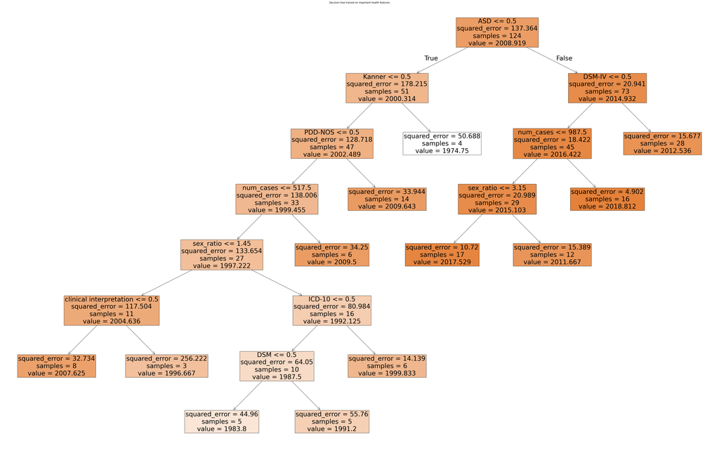

```python
plt.figure(figsize = [64, 40])
reg = DecisionTreeRegressor(max_leaf_nodes=12, min_samples_leaf=3,random_state=42).fit(X_train_tree, y_train_tree)
feature_names = reg.feature_names_in_
plot_tree(reg, filled=True, fontsize = 32, feature_names = feature_names, class_names=y_tree)
plt.title("Decision tree trained on important health features")
plt.show()
```

This line of code creates a visualization the decision tree's results based on the predictor and target variables. The decision tree begins with `ASD` as the top of the tree, making it the most important variable for predicting when a study was published. If more than half of individuals found within the study are affected by `ASD`, then the decision tree assumes that they were most likely diagnosed using the `DSM-IV`, which stands for *Diagnostic and Statistical Manual of Mental Disorders Version 4*, which is a version used by mental health professionals based on scientific literature to diagnose individuals with various mental disorders. This is denoted by a False result following arrows on the right. Continuing to the right, we can assume that these studies were published in 2012, as denoted the final false box on the right.

However, if less than half of these individuals are diagnosed using the `DSM-IV` version, then the decision tree checks for the number of recorded cases. If more than 987 autisic individuals were recorded in a study based on these 2 previous conditions, then we can assume that the study was conducted in 2019. Alternatively, if less than 987 autisitic individuals were recorded without using the `DSM-IV`, then the tree finally checks for the `sex_ratio`. In this case, if the ratio of autistic men to women is more than 3.15:1, then we can assume the study was conducted in 2012. Otherwise, the study was conducted in 2017.

If at most half of these individuals are affected by `Kanner`'s syndrome, the tree checks to see if they are also affected by `PDD-NOS`, which means pervasive developmental disorder, Not otherwise specified. These individuals have some autistic-like behaviors, but are not considered (classically) autistic. (Note: I was diagnosed with this when I was 4 years old.). If more than half of these individuals are affected by `PDD-NOS`, then the model assumes that these studies were conducted in 2010. However, if at most half of these individuals are affected by `PDD-NOS`, then the tree checks the number of cases recorded in each study. If more than 517 cases are recorded, the model assumes that a study was conducted in 2009. Otherwise, the model checks for the `sex_ratio` of a study.

Continuing with `sex_ratio` as the predictor, if it is more than 1.45, the model checks to see if these select individuals were diagnosed with the `ICD-10` code for `ASD`. This means the individual has pervasive developmental disorders, which is a specific code for `ASD`. If more than half of these individuals were diagnosed with this code, the model assumes that these studies were conducted in the year 2000. However, if at most half of these individuals were diagnosed with the `ICD-10` code, the model checks to see if they were diagnosed using the `DSM`, which is an earlier version of `DSM-IV`. If more than half of these individuals were diagnosed using the `DSM`, then the model assumes that these studies were published in 1991. Otherwise, the model predicts these studies to be conducted in 1984.

Going back to `sex_ratio`, if it is less than 1.45, then the tree checks to see if the diagnosis method was `clinical interpretation`, which means that a medical professional used their best judgement of autistic-like behaviors to diagnose those on the spectrum. If more than half of these cases were diagnosed using a `clinical interpretation`, then the tree assumes that the study was published in 1997. Otherwise, the model predicts that the study was conducted in 2008.

Overall, results found on the left of the decision tree, denoted by the "True" arrows are not to be trusted because they have very high squared_errors, ranging from 15 to a massive 256. Results on the right of the decision tree, as denoted by the first "False" arrow are more trustworthy because they have lower squared_error values, ranging from 5 to 21.

```python
for f,i in zip(feature_names, reg.feature_importances_):
    print(f,i)
```

```
survey 0.0
health records 0.0
service provider records 0.0
registry 0.0
education records 0.0
other method 0.0
special needs registry 0.0
Kanner 0.20785520073192593
clinical interpretation 0.019199409221322204
Rutter 0.0
DSM-III 0.0
autism test 0.0
other criterion 0.0
DSM-III-R 0.0
ICD-10 0.04179963617602358
parental report 0.0
ICD-9 0.0
DSM 0.010031912682182871
DSM-IV 0.01910500246547685
DMS-IV 0.0
special education classification 0.0
DSM-IV-TR 0.0
clinician interpretation 0.0
receipt of autism-specific services 0.0
receipt of autism specific services 0.0
survey 0.0
DSM-5 0.0
ICD-8 0.0
autistic-like conditions 0.0
Asperger syndrome 0.0
PDD 0.0
autism spectrum conditions 0.0
ASD 0.4701263243751279
high functioning autism 0.0
PDD-NOS 0.07477025441665748
early childhood autism 0.0
autistic mental retardation 0.0
childhood autism 0.0
childhood onset PDD 0.0
autistic disorder 0.0
autism 0.0
atypical autism 0.0
core autism 0.0
OMRS 0.0
num_cases 0.06462235532054714
color_ratio 0.0
sex_ratio 0.09248990461073602
```

The variables with the greatest importance include `ASD`, `Kanner`, `sex_ratio`, `num_cases`, and `PDD-NOS`. These variables will help determine hyperparamters when I fit my random forest regressor because they will make the model more accurate.

```python
target_year = "Year Published"
predictors_year = ['ASD', 'Kanner', 'sex_ratio', 'num_cases', 'PDD-NOS']
```

This line of code shows my new predictor variables that I chose based on their importance, which are `ASD`, `Kanner`, `sex_ratio`, `num_cases`, and `PDD-NOS` as predictors of the `Year Published` variable, which is the year a study was published

```python
X_year=pd.get_dummies(autism[predictors_year])
y_year=autism[target_year]

X_trainF, X_testF, y_trainF, y_testF = train_test_split(
    X_year,
    y_year,
    test_size=0.4,
    random_state=42)
```

```python
forest = RandomForestRegressor(max_leaf_nodes=12,min_samples_leaf=3,criterion="squared_error",random_state=42)
```

This line of code creates the random forest model with a maximum number of leaves of 12, a minimum number of samples per leaf being 3, measuring its results based on "squared error", and setting its seed to 42 for consistency.

```python
forest.fit(X_trainF,y_trainF)
```

```
RandomForestRegressor(max_leaf_nodes=12, min_samples_leaf=3, random_state=42)
```

This line of code fits the forest model based on the training data from the predictor and target variables.

```python
predictions_regF = forest.predict(X_testF)
```

This line of code predicts when a study was published based on the test data.

```python
residualsF = y_testF - predictions_regF
residualsF
```

```
161     4.799796
15     -2.618370
73     -3.660308
96     -5.971724
166    10.453327
         ...
41    -10.715793
128    -1.886598
78     -4.640866
175     4.137782
26     -2.042719
Name: Year Published, Length: 83, dtype: float64
```

I ran a residual test to see if the actual values of the `Year Published` statistic are similar to the ones my model predicted. After analyzing the results, I can tell that my model did a poor job of predicting the `Year Published` variable. This is because the values of the residuals are far away from zero. However, more validation steps need to be taken to prove if the model itself has an overall solid performance.

```python
print(f"Root mean squared error: {np.sqrt(mean_squared_error(y_testF, predictions_regF)):.2f}")
```

```
Root mean squared error: 5.78
```

This line of code calculates the Root Mean Squared Error (RMSE for short) because it allows me to determine the accuracy of my model's performance. In this case, the RMSE is 5.78. Since the range values in `Year Published` is between 1962 and 2021, this means that my model performed relatively well in predicting when a study was published.

```python
print(f"Coefficient of determination: {r2_score(y_testF, predictions_regF):.2f}")
```

```
Coefficient of determination: 0.60
```

I ran a calculation to determine the Coefficient of determination for my model. I did this to measure how strong my predicted values were compared to the actual results. Because my value is 0.60, I can deduce that there is some amount of variation from the actual values of when a study was published.

```python
results_year = pd.DataFrame({"predictions":predictions_regF, "residuals":residualsF})
results_year = results_year.dropna() # Drop all rows that have NaNs.
results_year
```

|  | predictions | residuals |
| --- | --- | --- |
| 161 | 2013.200204 | 4.799796 |
| 15 | 1991.618370 | -2.618370 |
| 73 | 2011.660308 | -3.660308 |
| 96 | 2016.971724 | -5.971724 |
| 166 | 2007.546673 | 10.453327 |
| ... | ... | ... |
| 41 | 2013.715793 | -10.715793 |
| 128 | 2016.886598 | -1.886598 |
| 78 | 2013.640866 | -4.640866 |
| 175 | 2014.862218 | 4.137782 |
| 26 | 2001.042719 | -2.042719 |

83 rows × 2 columns

I created a `results_year` DataFrame to determine if the histogram of residuals follows a normal distribution. This dataframe combines the `predictions_reg` and `residualsF` variables so that the histogram will be easier to code.

```python
alt.Chart(results_year, title="Histogram of Residuals").mark_bar().encode(
    x=alt.X('residuals:Q', title="Residuals").bin(maxbins=20),
    y=alt.Y('count():Q', title="Value Counts")
)
```

[interactive chart not shown]

```python
scores_reg = cross_val_score(forest, X_year, y_year, cv=5)
print(f"{scores_reg.mean():.3} accuracy with standard deviation {scores_reg.std():.3}")
```

```
-25.3 accuracy with standard deviation 15.9
```

I ran the random forest regressor model 5 more times to determine if it was accurate across multiple simulations. After running this model 5 more times, the average "accuracy" of this model is a large negative number (-25.3), meaning that the model performs worse across more and more simulations.

Also, the standard deviation of the 5 test models is 15.9, meaning the values of the results vary drastically. Taking into account my initial test, this model has produces worse and worse results across multiple simulations. When comparing this model to my other models, this out-of-sample validation has by far the worst performance.

These inferior results are not surprising given the fact that a random forest model generally performs well with the initial training set, but struggles with unknown data. Unfortunately, this cannot be fixed as the `autism` dataset has little data to work with.

## 4.2: Classifer Model

My final goal is to predict which country a study was conducted. Since there are so many countries that have only 1 recorded study, I decided to narrow down my dataset to include only three countries with the most recorded studies: The USA, England, and Sweden. Since this requires a classification model, I chose to use Naive Bayes as I believe that this type of model will perform better than my previous ones.

Note: Since I am checking three different countries, I do not need an ROC Curve or a `probabilities` DataFrame.

```python
autism_Countries = autism[(autism.Country == "USA") | (autism.Country == "England") | (autism.Country == "Sweden")]
```

This line of code creates a subset of the `autism` dataset to only include studies conducted in the USA, England, or Sweden.

```python
target_country = 'Country'
predictors_country = ['num_cases'] + method
```

For my classification test, I chose `num_cases` as well as the methods used in each study as predictors for which country as study was conducted in.

```python
from sklearn.naive_bayes import MultinomialNB
from sklearn.metrics import confusion_matrix, classification_report
```

Because I am using a (Naive Bayes) Classification Model, I will need to import the following libraries:

- MultinomailNB: The Naive Bayes Classifier Model itself
- confusion_matrix: Creates a confusion matrix of the classification model
- classification_report: Returns the overall results of the classification model's performance.

```python
X_country = pd.get_dummies(autism_Countries[predictors_country]) # One-hot encoding
y_country = autism_Countries[target_country] # Creating a y to keep our code cleaner

X_train_country, X_test_country, y_train_country, y_test_country = train_test_split(
    X_country,
    y_country,
    test_size=4/9,
    random_state=42)
```

This line of code assigns my predictors to the `X_country` variable and the target to the `y_country` for the naive bayes model. Much like all of my previous models, this code also splits the data into training and testing portions.

```python
naive_model = MultinomialNB(alpha=0.01, fit_prior=True)
naive_model.fit(X_train_country,y_train_country)
```

```
MultinomialNB(alpha=0.01)
```

This block of code creates a naive bayes model with `alpha` set to 0.01 to help with zeroes, while making sure to use prior probabilities by setting `fit_prior` to **True**. This block of code then fits the `naive_model` to the training data for my `X_country` and `y_country` variables.

```python
predictions_country = naive_model.predict(X_test_country)
```

This line of code creates the`predictions_country` variable based on the predictions that the naive bayes classifier model makes based on the test data to determine if a study was conducted in the US, England, or Sweden.

```python
categories = naive_model.classes_
```

This line of code creates the `categories` variable to determine if my chosen studies were conducted in the US, England, or Sweden.

```python
# Calculate confusion matrix and transform data
conf_mat = confusion_matrix(y_test_country,predictions_country)
conf_mat = pd.DataFrame(conf_mat,index=categories,columns=categories)
conf_mat = conf_mat.melt(ignore_index=False).reset_index()
conf_mat
```

|  | index | variable | value |
| --- | --- | --- | --- |
| 0 | England | England | 2 |
| 1 | Sweden | England | 1 |
| 2 | USA | England | 16 |
| 3 | England | Sweden | 0 |
| 4 | Sweden | Sweden | 2 |
| 5 | USA | Sweden | 2 |
| 6 | England | USA | 3 |
| 7 | Sweden | USA | 4 |
| 8 | USA | USA | 10 |

In this step, I created a confusion matrix to determine how well the model performed. This confusion matrix is based on the testing data for my target variable, as well as the predictions my model made.

```python
# Create heatmap
heatmap = alt.Chart(conf_mat).mark_rect().encode(
    x=alt.X("variable:N").title("Predicted Response"),
    y=alt.Y("index:N").title("True Response"),
    color=alt.Color("value:Q", legend=None).scale(scheme="blues")
).properties(
    width=400,
    height=400
)
# Add text labels for numbers
text = heatmap.mark_text(baseline="middle").encode(
    text=alt.Text("value:Q"),
    color=alt.value("black"),
    size=alt.value(50)
)

heatmap + text
```

[interactive chart not shown]

```python
print(classification_report(y_test_country, predictions_country))
```

```
              precision    recall  f1-score   support

     England       0.11      0.40      0.17         5
      Sweden       0.50      0.29      0.36         7
         USA       0.59      0.36      0.44        28

    accuracy                           0.35        40
   macro avg       0.40      0.35      0.32        40
weighted avg       0.51      0.35      0.40        40
```

In order to validate my model, I will need to perform a `classification_report` to obtain my accuracy scores. Looking at the report, only 35% of studies were correctly classified. The precision scores for England, Sweden, and the USA were 0.11, 0.50, and 0.59, respectively. This means that the model correctly predicted 11% of studies in the test data to be from England, 50% of studies in the test data to be from Sweden, and 59% of studies to be conducted in the USA.

The recall scores for England, Sweden, and the USA were 0.40, 0.29, and 0.36, respectively. This means that 40% of all studies that were conducted in England were correctly classified, 29% of studies that were conducted in Sweden were correctly classified, and 36% of studies conducted in the USA were correctly classified.

Note: Since this is not a binary classification model, there is no specificity (which is the recall score of the other category).

Based on these results, I can conclude that the model performed poorly due to the low accuracy, precision, and recall scores.

```python
scores = cross_val_score(naive_model, X_country, y_country, cv=5)
print(f"{scores.mean():.2} accuracy with standard deviation {scores.std():.2}")
```

```
0.64 accuracy with standard deviation 0.09
```

In this step, I ran cross-validation of the naive bayes classification model to determine if the model itself was accurate across multiple simulations. I chose to run 5 more models with different training and test data. The results show that on average, the model itself is accurate 64% of the time with a standard deviation score of 0.09. This means that this particular model has the most consistent performance when predicting if studies were conducted in the USA, England, or Sweden. However, based on the results of my iniial model, I can conclude that it (the Naive Bayes Model) has performs poorly overall. When comparing it to my other 3 models, this model has no better performance when predicting if a study took place in the USA, England, or Sweden.

# **5: Conclusion**

Overall, there is a positive correlation between a study’s sample size and the number of autistic individuals diagnosed in each sample. These results can be trusted because the p-value for my hypothesis test was exactly 0.0, and the correlation coefficient between `sample_size` and `num_cases` was around 0.7. However, there is not enough data to answer my other questions. This is because all of my other models had mediocre results at best, and at worst could not predict when a study was published. This could be corrected by choosing a dataset with more data about autism prevalence.

Despite my models’ poor results, many studies find that individuals are usually diagnosed by the age of 2 and there is no specific “cutoff” age when autism cannot be diagnosed. These studies can be verified by Autism Speaks, Autism Statistics and Facts. However, these facts are not in a dataset for study. I would still like to see if any dataset is able to correctly predict my hypothesis questions in the future.